# exploratory_personality_with_MI

2023-03-29

```r
library(Rmisc)
library(Hmisc)
library(rio)
library(tidyverse)
library(psych)
library(gtools) # rbinding data frames
library(corrplot)
library(jtools) # for pretty printing tables
library(sjPlot) # pretty printing tables
library(sjmisc) # pretty printing
library(mice) # handling missing values
library(naniar) # visualizaing missingness & MCAR test
library(miceadds) # for mi.anova
library(emmeans) # simple effects analyses
library(broom)     # for extracting residuals and outlier indices
library(olsrr)     # for creating outlier plots
library(smcfcs) # for multiple imputation with interactions
library(mitools) # for pooling MI results
library(marginaleffects) # for plotting marginal means
library(installr)

options(max.print = 100000) # max rows to print in output
options(scipen = 1000) # turn off sci notation
```

# Data Import & Cleaning

## Import data

```r
raw_psych_hum_subj <- import("data/raw/raw_psych_hum_subj.csv")
raw_mktg_hum_subj <- import("data/raw/raw_mktg_hum_subj.csv")
raw_gen_uo_pop <- import("data/raw/raw_gen_uo_pop.csv")
pre_fall22 <- import("data/prescreen/dittersdorf_matches_f22.csv")
pre_winter23 <- import("data/prescreen/dittersdorf_matches_w23.csv")
pre_spring23 <- import("data/prescreen/dittersdorf_matches_s23.csv")
participant_list <- import("data/prescreen/dittersdorf_participants.csv")
```

Inspect data

```r
# Main Data
str(raw_psych_hum_subj, list.len = ncol(raw_psych_hum_subj))
str(raw_mktg_hum_subj, list.len = ncol(raw_mktg_hum_subj))
str(raw_gen_uo_pop, list.len = ncol(raw_gen_uo_pop))
```

## Change variables types

```r
raw_psych_hum_subj <- raw_psych_hum_subj %>%
  mutate(Age = as.integer(Age),
         Gender = as.factor(Gender),
         framing_condition_DO = as.factor(framing_condition_DO),
         norm_condition_DO = as.factor(norm_condition_DO),
         consumer_behaviors = as.factor(consumer_behaviors),
         skepticism = as.factor(skepticism),
         id = as.factor(id))

raw_mktg_hum_subj <- raw_mktg_hum_subj %>%
  mutate(Age = as.integer(Age),
         Gender = as.factor(Gender),
         Gender_5_TEXT = as.character(Gender_5_TEXT),
         Class_Lvl_7_TEXT = as.character(Class_Lvl_7_TEXT),
         Pol_Ornt_8_TEXT = as.character(Pol_Ornt_8_TEXT),
         Ethnicity_8_TEXT = as.character(Ethnicity_8_TEXT),
         skept_open = as.character(skept_open),
         skepticism = as.factor(skepticism),
         id = as.factor(id),
         framing_condition_DO = as.factor(framing_condition_DO),
         norm_condition_DO = as.factor(norm_condition_DO),
         consumer_behaviors = as.factor(consumer_behaviors))

raw_gen_uo_pop <- raw_gen_uo_pop %>%
  mutate(Gender = as.factor(Gender),
         Gender_5_TEXT = as.character(Gender_5_TEXT),
         Class_Lvl_7_TEXT = as.character(Class_Lvl_7_TEXT),
         Pol_Ornt_8_TEXT = as.character(Pol_Ornt_8_TEXT),
         skept_open = as.character(skept_open),
         skepticism = as.factor(skepticism),
         id = as.factor(id),
         framing_condition_DO = as.factor(framing_condition_DO),
         norm_condition_DO = as.factor(norm_condition_DO),
         consumer_behaviors = as.factor(consumer_behaviors))
```

Inspect prescreen data

```r
# Prescreen Data
str(pre_fall22, list.len = ncol(pre_fall22))
str(pre_winter23, list.len = ncol(pre_winter23))
str(pre_spring23, list.len = ncol(pre_spring23))
str(participant_list, list.len = ncol(participant_list))
```

Variables from prescreen:

- Values:
  - respecting, unity, protecting, preventing, equality, peace, justice, helpful, power, wealth, authority, influential, ambition, pleasures, enjoying, gratification
- Socially Desirable Responding:
  - honest, like, disturbing, regret, lose-out, rational, confident, lover, lies, cover-up, advantage, get-even, behind-back, private-talk, take-things, gossip

## Combine prescreen data

Specify unique variables to combine prescreen data sets

```r
# Create unique full_name variable
pre_fall22$full_name <- paste(pre_fall22$first_name, pre_fall22$last_name, sep="_")

pre_winter23$full_name <- paste(pre_winter23$first_name, pre_winter23$last_name, sep="_")

pre_spring23$full_name <- paste(pre_spring23$first_name, pre_spring23$last_name, sep="_")

participant_list$full_name <- paste(participant_list$first_name, participant_list$last_name, sep="_")

# Create column indicating which data set rows came from

pre_fall22 <- pre_fall22 %>%
  mutate(term = "fall22")

pre_winter23 <- pre_winter23 %>%
  mutate(term = "winter23")

pre_spring23 <- pre_spring23 %>%
  mutate(term = "spring23")
```

Combine prescreen data

```r
combine1 <- smartbind(pre_fall22, pre_winter23)
combined_prescreen <- smartbind(combine1, pre_spring23)

nrow(pre_fall22) + nrow(pre_winter23) + nrow(pre_spring23) # n = 1167
```

```
## [1] 1167
```

```r
combined_prescreen_unique <- combined_prescreen[!duplicated(combined_prescreen$full_name), ] # keeps first row (fall22)
```

Subset key variables

```r
combined_prescreen_key <- combined_prescreen_unique %>%
  select(full_name, term, respecting:gratification, honest:gossip)

participant_list_key <- participant_list %>%
  select(full_name, survey_id)
```

Merge with participant list

```r
merged_prescreen <- merge(combined_prescreen_key, participant_list_key, by = "full_name")
```

Convert variable types in prescreen data

```r
str(merged_prescreen, list.len = ncol(merged_prescreen))
```

```r
merged_prescreen <- merged_prescreen %>%
  rename("lose_out" = "lose-out",
         "cover_up" = "cover-up",
         "get_even" = "get-even",
         "behind_back" = "behind-back",
         "private_talk" = "private-talk",
         "take_things" = "take-things",
         "id" = "survey_id")

merged_prescreen <- merged_prescreen %>%
  mutate(respecting = as.integer(respecting),
         unity = as.integer(unity),
         protecting = as.integer(protecting),
         preventing = as.integer(preventing),
         equality = as.integer(equality),
         peace = as.integer(peace),
         justice = as.integer(justice),
         helpful = as.integer(helpful),
         power = as.integer(power),
         wealth = as.integer(wealth),
         authority = as.integer(authority),
         influential = as.integer(influential),
         ambition = as.integer(ambition),
         pleasures = as.integer(pleasures),
         enjoying = as.integer(enjoying),
         gratification = as.integer(gratification),
         honest = as.integer(honest),
         like = as.integer(like),
         disturbing = as.integer(disturbing),
         regret = as.integer(regret),
         lose_out = as.integer(lose_out),
         rational = as.integer(rational),
         confident = as.integer(confident),
         lover = as.integer(lover),
         lies = as.integer(lies),
         cover_up = as.integer(cover_up),
         advantage = as.integer(advantage),
         get_even = as.integer(get_even),
         behind_back = as.integer(behind_back),
         private_talk = as.integer(private_talk),
         take_things = as.integer(take_things),
         gossip = as.integer(gossip),
         id = as.factor(id))
```

Rename values & socially desirable items in prescreen data to match names in main data:

```r
merged_prescreen <- merged_prescreen %>%
  rename("values_1" = "respecting",
         "values_2" = "unity",
         "values_3" = "protecting",
         "values_4" = "preventing",
         "values_5" = "equality",
         "values_6" = "peace",
         "values_7" = "justice",
         "values_8" = "helpful",
         "values_9" = "power",
         "values_10" = "wealth",
         "values_11" = "authority",
         "values_12" = "influential",
         "values_13" = "ambition",
         "values_14" = "pleasures",
         "values_15" = "enjoying",
         "values_16" = "gratification",
         "socially_desirable_1" = "honest",
         "socially_desirable_2" = "like",
         "socially_desirable_3" = "disturbing",
         "socially_desirable_4" = "regret",
         "socially_desirable_5" = "lose_out",
         "socially_desirable_6" = "rational",
         "socially_desirable_7" = "confident",
         "socially_desirable_8" = "lover",
         "socially_desirable_9" = "lies",
         "socially_desirable_10" = "cover_up",
         "socially_desirable_11" = "advantage",
         "socially_desirable_12" = "get_even",
         "socially_desirable_13" = "behind_back",
         "socially_desirable_14" = "private_talk",
         "socially_desirable_15" = "take_things",
         "socially_desirable_16" = "gossip")
```

## Combine all data

- First, combine Psych Hum Subj data with Prescreen data based on `id`
- Second, add Mktg Hum Subj data
- Third, add gen UO Pop data

```r
combine1 <- merge(raw_psych_hum_subj, merged_prescreen, by = "id")
combine2 <- smartbind(combine1, raw_mktg_hum_subj)
combine3 <- smartbind(combine2, raw_gen_uo_pop)
```

## Remove duplicate cases

Identify duplicate cases

```r
# first, add unique row #s
combine3 <- combine3 %>%
  mutate(row = 1:nrow(combine3))

combine3[duplicated(combine3$id),] # Only rows 1 through 858 have unique id #s

# write.csv(combine3, "combined_data.csv")
```

Row IDs to remove:

- 13 (participant’s second time completing study)
- 134 (participant didn’t complete study first time)
- 145 (participant didn’t complete study first time)
- 308 (participant’s second time completing study)
- 672 (participant’s second time completing study)
- 743 (participant didn’t complete study first time)
- 790 (participant didn’t complete study first time)
- 800 (participant didn’t complete study first time)

Remove duplicate rows after resolving:

```r
combine3 <- combine3 %>%
  filter(!row %in% c(13, 134, 145, 308, 672, 743, 790, 800))
```

Check variables types again

```r
str(combine3, list.len = ncol(combine3))
```

## Remove all NA cases

Identify completely missing rows:

```r
key_vars <- combine3 %>%
  select(row, big_2_1:big_2_65, consumer_intentions_1:consumer_intentions_9, consumer_behaviors, clothing_interest_1:clothing_interest_20, ingroup_ident_1:ingroup_ident_14, values_1:values_16, socially_desirable_1:socially_desirable_16)

ncol(key_vars) # number of columns - the row # column = 141

all_NA_rows <- key_vars[rowSums(is.na(key_vars)) == 141,] # identify rows with 142 NAs (all missing values), row numbers are preserved

all_NA_rows
```

Removing rows of fully missing data:

```r
data <- combine3 %>%
  filter(!row %in% c(859, 860, 900, 926, 927, 941, 1139, 1141, 1142, 1143, 1144, 1146, 1149, 1150, 1152)) %>% # remove rows containing all NAs
  select(-StartDate, -EndDate, -Status, -Progress, -"Duration (in seconds)", -Finished, -RecordedDate, -ResponseId, -DistributionChannel, -UserLanguage, -big_2_DO, -consumer_intentions_DO, -consumer_behaviors_DO, -clothing_interest_DO, -ingroup_ident_DO, -full_name, -code, -socially_desirable_DO, -values_DO, -email_giftcard, -term) # removing variables not in analysis
```

Rename variables:

```r
data <- data %>%
  rename("framing_condition" = "framing_condition_DO",
         "norm_condition" = "norm_condition_DO")

levels(data$framing_condition)
```

```
## [1] ""                 "control_framing"  "pro_env_framing"  "self_enh_framing"
```

```r
levels(data$norm_condition)
```

```
## [1] ""                 "control_norm"     "convention_norm"  "descriptive_norm"
## [5] "moral_norm"       "social_norm"
```

```r
data$framing_condition <- droplevels(data$framing_condition)
data$norm_condition <- droplevels(data$norm_condition)

levels(data$framing_condition)
```

```
## [1] "control_framing"  "pro_env_framing"  "self_enh_framing"
```

```r
levels(data$norm_condition)
```

```
## [1] "control_norm"     "convention_norm"  "descriptive_norm" "moral_norm"
## [5] "social_norm"
```

```r
levels(data$skepticism)
```

```
## [1] "1" "2"
```

## Inspect final data

```r
str(data, list.len = ncol(data))

# write.csv(data, "final_data.csv")
```

## Demographics

Age

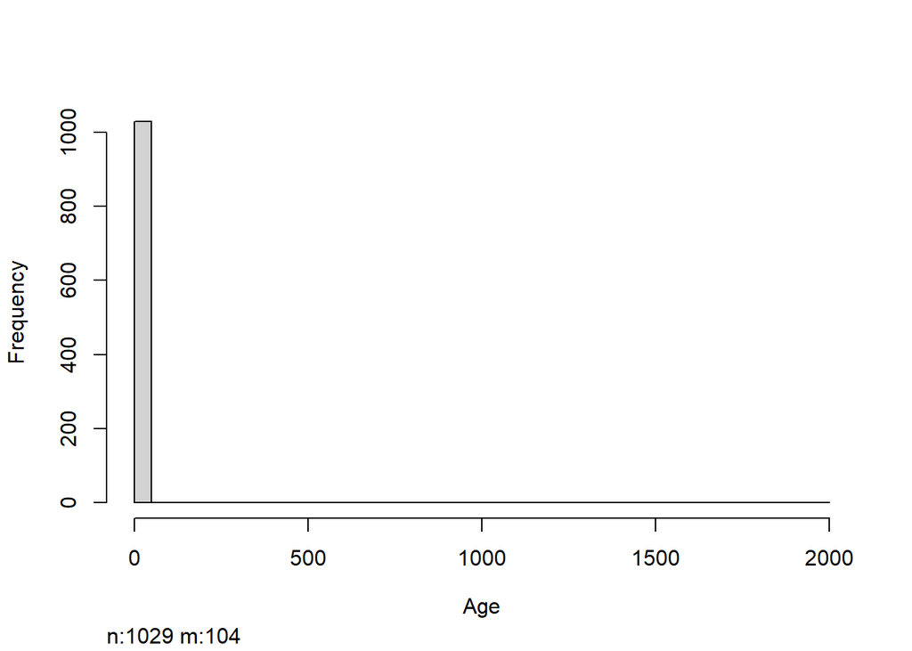

```r
# Age
data %>%
  select(Age) %>%
  hist()
```

```r
describe(data$Age) # 1999 a data entry error
```

```
##    vars    n mean    sd median trimmed  mad min  max range  skew kurtosis   se
## X1    1 1029 21.8 61.73     19   19.67 1.48  18 1999  1981 31.94  1019.96 1.92
```

```r
data %>%
  filter(Age == 1999) # Row 1053, Year 1999 = 24 years old
```

```
##           id big_2_1 big_2_2 big_2_3 big_2_4 big_2_5 big_2_6 big_2_7 big_2_8
## 1:1053 43012       2       2       4       4       2       3       4       4
##        big_2_9 big_2_10 big_2_11 big_2_12 big_2_13 big_2_14 big_2_15 big_2_16
## 1:1053       4        4        2        4        4        3        3        5
##        big_2_17 big_2_18 big_2_19 big_2_20 big_2_21 big_2_22 big_2_23 big_2_24
## 1:1053        3        4        5        4        3        3        4        5
##        big_2_25 big_2_26 big_2_27 big_2_28 big_2_29 big_2_30 big_2_31 big_2_32
## 1:1053        3        4        3        4        3        4        4        1
##        big_2_33 big_2_34 big_2_35 big_2_36 big_2_37 big_2_38 big_2_39 big_2_40
## 1:1053        4        4        3        3        3        3        3        4
##        big_2_41 big_2_42 big_2_43 big_2_44 big_2_45 big_2_46 big_2_47 big_2_48
## 1:1053        2        4        3        4        3        2        5        3
##        big_2_49 big_2_50 big_2_51 big_2_52 big_2_53 big_2_54 big_2_55 big_2_56
## 1:1053        2        2        4        4        3        3        2        3
##        big_2_57 big_2_58 big_2_59 big_2_60 big_2_61 big_2_62 big_2_63 big_2_64
## 1:1053        2        4        3        2        4        4        1        3
##        big_2_65 consumer_intentions_1 consumer_intentions_2
## 1:1053        4                     2                     5
##        consumer_intentions_3 consumer_intentions_4 consumer_intentions_5
## 1:1053                     2                     6                     2
##        consumer_intentions_6 consumer_intentions_7 consumer_intentions_8
## 1:1053                     1                     7                     1
##        consumer_intentions_9 consumer_behaviors clothing_interest_1
## 1:1053                     7                  1                   4
##        clothing_interest_2 clothing_interest_3 clothing_interest_4
## 1:1053                   4                   3                   4
##        clothing_interest_5 clothing_interest_6 clothing_interest_7
## 1:1053                   2                   3                   1
##        clothing_interest_8 clothing_interest_9 clothing_interest_10
## 1:1053                   4                   5                    3
##        clothing_interest_11 clothing_interest_12 clothing_interest_13
## 1:1053                    4                    2                    4
##        clothing_interest_14 clothing_interest_15 clothing_interest_16
## 1:1053                    1                    2                    2
##        clothing_interest_17 clothing_interest_18 clothing_interest_19
## 1:1053                    4                    1                    2
##        clothing_interest_20 ingroup_ident_1 ingroup_ident_2 ingroup_ident_3
## 1:1053                    2               1               1               2
##        ingroup_ident_4 ingroup_ident_5 ingroup_ident_6 ingroup_ident_7
## 1:1053               4               4               4               4
```

[output cut: 11 more lines]

```
## 1:1053  self_enh_framing     moral_norm        2        0        1        1
##        values_5 values_6 values_7 values_8 values_9 values_10 values_11
## 1:1053        1        2        1        0        3         3         3
##        values_12 values_13 values_14 values_15 values_16 socially_desirable_1
## 1:1053         1         1         1         2         2                    5
##        socially_desirable_2 socially_desirable_3 socially_desirable_4
## 1:1053                    7                    5                    4
##        socially_desirable_5 socially_desirable_6 socially_desirable_7
## 1:1053                    3                    5                    6
##        socially_desirable_8 socially_desirable_9 socially_desirable_10
## 1:1053                    5                    6                     6
##        socially_desirable_11 socially_desirable_12 socially_desirable_13
## 1:1053                     5                     4                     4
##        socially_desirable_14 socially_desirable_15 socially_desirable_16  row
## 1:1053                     2                     5                     3 1053
```

```r
data$Age[data$Age == 1999] <- 24

data %>%
  filter(row == 1053) %>%
  select(Age) # Age has been replaced with 24
```

```
##        Age
## 1:1053  24
```

Gender

- 1 = woman
- 2 = man
- 3 = non-binary
- 4 = I prefer not to identify
- 5 = other (please specify)

```r
levels(data$Gender) <- c("Woman", "Man", "Non-binary", "I prefer not to identify", "Other")
```

# Aggregate Variables

## Personality

### Reverse-code

```r
data_R <- data %>%
  mutate(across(c(big_2_11,
                  big_2_16,
                  big_2_26,
                  big_2_31,
                  big_2_36,
                  big_2_51,
                  big_2_12,
                  big_2_17,
                  big_2_22,
                  big_2_37,
                  big_2_42,
                  big_2_47,
                  big_2_3,
                  big_2_8,
                  big_2_23,
                  big_2_28,
                  big_2_48,
                  big_2_58,
                  big_2_4,
                  big_2_9,
                  big_2_24,
                  big_2_29,
                  big_2_44,
                  big_2_49,
                  big_2_5,
                  big_2_25,
                  big_2_30,
                  big_2_45,
                  big_2_50,
                  big_2_55,
                  big_2_63), ~6 - .)) # replace '6' with the max possible value plus 1 for any particular scale
```

### Average items

```r
data_R$extraversion <- data_R %>%
  select(big_2_1, big_2_6, big_2_11, big_2_16, big_2_21, big_2_26, big_2_31, big_2_36, big_2_41, big_2_46, big_2_51, big_2_56) %>%
  rowMeans(na.rm = TRUE)


data_R$conscientiousness <- data_R %>%
  select(big_2_3, big_2_8, big_2_13, big_2_18, big_2_23, big_2_28, big_2_33, big_2_38, big_2_43, big_2_48, big_2_53, big_2_58) %>%
  rowMeans(na.rm = TRUE)


data_R$agreeableness <- data_R %>%
  select(big_2_2, big_2_7, big_2_12, big_2_17, big_2_22, big_2_27, big_2_32, big_2_37, big_2_42, big_2_47, big_2_52, big_2_57) %>%
  rowMeans(na.rm = TRUE)


data_R$neuroticism <- data_R %>%
  select(big_2_4, big_2_9, big_2_14, big_2_19, big_2_24, big_2_29, big_2_34, big_2_39, big_2_44, big_2_49, big_2_54, big_2_59) %>%
  rowMeans(na.rm = TRUE)


data_R$openness <- data_R %>%
  select(big_2_5, big_2_10, big_2_15, big_2_20, big_2_25, big_2_30, big_2_35, big_2_40, big_2_45, big_2_50, big_2_55, big_2_60) %>%
  rowMeans(na.rm = TRUE)


data_R$honesty <- data_R %>%
  select(big_2_61, big_2_62, big_2_63, big_2_64, big_2_65) %>%
  rowMeans(na.rm = TRUE)
```

## Clothing Interest

### Reverse-code

```r
data_R <- data_R %>%
  mutate(across(c(clothing_interest_3,
                  clothing_interest_5,
                  clothing_interest_7,
                  clothing_interest_9,
                  clothing_interest_12,
                  clothing_interest_14,
                  clothing_interest_15,
                  clothing_interest_16,
                  clothing_interest_18,
                  clothing_interest_20), ~6 - .)) # replace '#' with the max possible value plus 1 for any particular scale
```

### Average items

```r
data_R$clothing_interest <- data_R %>%
  select(clothing_interest_1:clothing_interest_20) %>%
  rowMeans(na.rm = TRUE)
```

## In-group Identification

### Reverse-code

No items need to be reverse-coded.

### Average items

```r
data_R$ingroup_identification <- data_R %>%
  select(ingroup_ident_1:ingroup_ident_14) %>%
  rowMeans(na.rm = TRUE)
```

## Values

### Reverse-code

No items need to be reverse-coded.

### Recoding scale options

Recoding values:

- -3 = 1
- -2 = 2
- -1 = 3
- 0 = 4
- +1 = 5
- +2 = 6
- +3 = 7

```r
table(data_R$values_1)
```

```
##
##  -3  -2  -1   0   1   2   3
##   5  10  17  40 176 362 508
```

```r
data_R$values_1_rec <- recode(data_R$values_1, `-3` = 1, `-2` = 2, `-1` = 3, `0` = 4, `1` = 5, `2` = 6, `3` = 7)

table(data_R$values_1_rec)
```

```
##
##   1   2   3   4   5   6   7
##   5  10  17  40 176 362 508
```

```r
data_R$values_2_rec <- recode(data_R$values_2, `-3` = 1, `-2` = 2, `-1` = 3, `0` = 4, `1` = 5, `2` = 6, `3` = 7)
data_R$values_3_rec <- recode(data_R$values_3, `-3` = 1, `-2` = 2, `-1` = 3, `0` = 4, `1` = 5, `2` = 6, `3` = 7)
data_R$values_4_rec <- recode(data_R$values_4, `-3` = 1, `-2` = 2, `-1` = 3, `0` = 4, `1` = 5, `2` = 6, `3` = 7)
data_R$values_5_rec <- recode(data_R$values_5, `-3` = 1, `-2` = 2, `-1` = 3, `0` = 4, `1` = 5, `2` = 6, `3` = 7)
data_R$values_6_rec <- recode(data_R$values_6, `-3` = 1, `-2` = 2, `-1` = 3, `0` = 4, `1` = 5, `2` = 6, `3` = 7)
data_R$values_7_rec <- recode(data_R$values_7, `-3` = 1, `-2` = 2, `-1` = 3, `0` = 4, `1` = 5, `2` = 6, `3` = 7)
data_R$values_8_rec <- recode(data_R$values_8, `-3` = 1, `-2` = 2, `-1` = 3, `0` = 4, `1` = 5, `2` = 6, `3` = 7)
data_R$values_9_rec <- recode(data_R$values_9, `-3` = 1, `-2` = 2, `-1` = 3, `0` = 4, `1` = 5, `2` = 6, `3` = 7)
data_R$values_10_rec <- recode(data_R$values_10, `-3` = 1, `-2` = 2, `-1` = 3, `0` = 4, `1` = 5, `2` = 6, `3` = 7)
data_R$values_11_rec <- recode(data_R$values_11, `-3` = 1, `-2` = 2, `-1` = 3, `0` = 4, `1` = 5, `2` = 6, `3` = 7)
data_R$values_12_rec <- recode(data_R$values_12, `-3` = 1, `-2` = 2, `-1` = 3, `0` = 4, `1` = 5, `2` = 6, `3` = 7)
data_R$values_13_rec <- recode(data_R$values_13, `-3` = 1, `-2` = 2, `-1` = 3, `0` = 4, `1` = 5, `2` = 6, `3` = 7)
data_R$values_14_rec <- recode(data_R$values_14, `-3` = 1, `-2` = 2, `-1` = 3, `0` = 4, `1` = 5, `2` = 6, `3` = 7)
data_R$values_15_rec <- recode(data_R$values_15, `-3` = 1, `-2` = 2, `-1` = 3, `0` = 4, `1` = 5, `2` = 6, `3` = 7)
data_R$values_16_rec <- recode(data_R$values_16, `-3` = 1, `-2` = 2, `-1` = 3, `0` = 4, `1` = 5, `2` = 6, `3` = 7)

table(data_R$values_16)
```

```
##
##  -3  -2  -1   0   1   2   3
##   4  11  29 116 250 394 312
```

```r
table(data_R$values_16_rec)
```

```
##
##   1   2   3   4   5   6   7
##   4  11  29 116 250 394 312
```

### Average items

```r
data_R$biospheric <- data_R %>%
  select(values_1_rec:values_4_rec) %>%
  rowMeans(na.rm = TRUE)

data_R$altruistic <- data_R %>%
  select(values_5_rec:values_8_rec) %>%
  rowMeans(na.rm = TRUE)

data_R$egoistic <- data_R %>%
  select(values_9_rec:values_13_rec) %>%
  rowMeans(na.rm = TRUE)

data_R$hedonic <- data_R %>%
  select(values_14_rec:values_16_rec) %>%
  rowMeans(na.rm = TRUE)
```

## Socially Desirable Responding

### Reverse-code

```r
data_R <- data_R %>%
  mutate(across(c(socially_desirable_1,
                  socially_desirable_3,
                  socially_desirable_5,
                  socially_desirable_8,
                  socially_desirable_9,
                  socially_desirable_11,
                  socially_desirable_12,
                  socially_desirable_13), ~8 - .)) # replace '#' with the max possible value plus 1 for any particular scale
```

### Average items

```r
data_R$socially_desirable <- data_R %>%
  select(socially_desirable_1:socially_desirable_16) %>%
  rowMeans(na.rm = TRUE)
```

## Consumer Intentions

### Reverse-code

Higher scores mean better consumer intentions (intentions to *reduce* future consumption):

```r
data_R <- data_R %>%
  mutate(across(c(consumer_intentions_2,
                  consumer_intentions_4,
                  consumer_intentions_7,
                  consumer_intentions_9), ~8 - .)) # replace '#' with the max possible value plus 1 for any particular scale
```

### Average items

```r
data_R$consumer_intentions <- data_R %>%
  select(consumer_intentions_1:consumer_intentions_9) %>%
  rowMeans(na.rm = TRUE)
```

### Reorder levels

Reorder the levels of norm condition:

```r
data_R %>%
  group_by(norm_condition) %>%
  summarize(M = mean(consumer_intentions, na.rm = TRUE))
```

```
## # A tibble: 5 × 2
##   norm_condition       M
##   <fct>            <dbl>
## 1 control_norm      4.46
## 2 convention_norm   4.55
## 3 descriptive_norm  4.42
## 4 moral_norm        4.34
## 5 social_norm       4.30
```

```r
data_R$norm_condition <- factor(data_R$norm_condition, levels = c("control_norm", "descriptive_norm", "convention_norm", "social_norm", "moral_norm"))
```

# Regression Analysis for Consumer Intentions

## Center Covariates

- Socially desirable responding
- Clothing interest
- Values
- Ingroup identification
- Age
- Gender
- Income (not sure how to handle inconsistencies in this variable was responded to)

## Multiple Imputation using `smcfcs` - alt Coding Approach

## Contrast Coding

Data to practice alt approach on:

Contrast Coding using ifelse() approach:

```r
# Gender
#data_R_alt$GenderCode <- ifelse(data_R$Gender == "Woman", 1, 0)

# Framing X Norm
#data_R_alt$framingXnorm <- interaction(data_R_alt$framing_condition, data_R_alt$norm_condition)


# Framing
data_R_alt$FramingCode1 <- ifelse(data_R_alt$framing_condition == "control_framing", -1/2, ifelse(data_R_alt$framing_condition == "self_enh_framing", 1/2, 0))

data_R_alt$FramingCode2 <- ifelse(data_R_alt$framing_condition == "pro_env_framing", 2/3, -1/3)

# Norm
contr.helmert(5)
```

```
##   [,1] [,2] [,3] [,4]
## 1   -1   -1   -1   -1
## 2    1   -1   -1   -1
## 3    0    2   -1   -1
## 4    0    0    3   -1
## 5    0    0    0    4
```

```r
data_R_alt$NormCode1 <- ifelse(data_R_alt$norm_condition == "moral_norm", 4, -1)

data_R_alt$NormCode2 <- ifelse(data_R_alt$norm_condition == "social_norm", 3, ifelse(data_R_alt$norm_condition == "moral_norm", 0, -1))

data_R_alt$NormCode3 <- ifelse(data_R_alt$norm_condition == "convention_norm", 2, ifelse(data_R_alt$norm_condition == "moral_norm", 0, ifelse(data_R_alt$norm_condition == "social_norm", 0, -1)))
data_R_alt$NormCode4 <- ifelse(data_R_alt$norm_condition == "descriptive_norm", 1, ifelse(data_R_alt$norm_condition == "control_norm", -1, 0))


## Adding contrast codes to Framing & Norm Condition
# Framing
FrameCode1 <- c(-1/2, 0, 1/2) # control vs self-enhancing
FrameCode2 <- c(-1/3, 2/3, -1/3) # arbitrary code

contrasts(data_R_alt$framing_condition) <- cbind(FrameCode1, FrameCode2)
contrasts(data_R_alt$framing_condition)
```

```
##                  FrameCode1 FrameCode2
## control_framing        -0.5 -0.3333333
## pro_env_framing         0.0  0.6666667
## self_enh_framing        0.5 -0.3333333
```

```r
# Norm
contrasts(data_R_alt$norm_condition) <- contr.helmert(5)
contrasts(data_R_alt$norm_condition) # control vs DN
```

```
##                  [,1] [,2] [,3] [,4]
## control_norm       -1   -1   -1   -1
## descriptive_norm    1   -1   -1   -1
## convention_norm     0    2   -1   -1
## social_norm         0    0    3   -1
## moral_norm          0    0    0    4
```

```r
# Gender
contrasts(data_R_alt$Gender) <- c(1, 0)
```

Examine missingness:

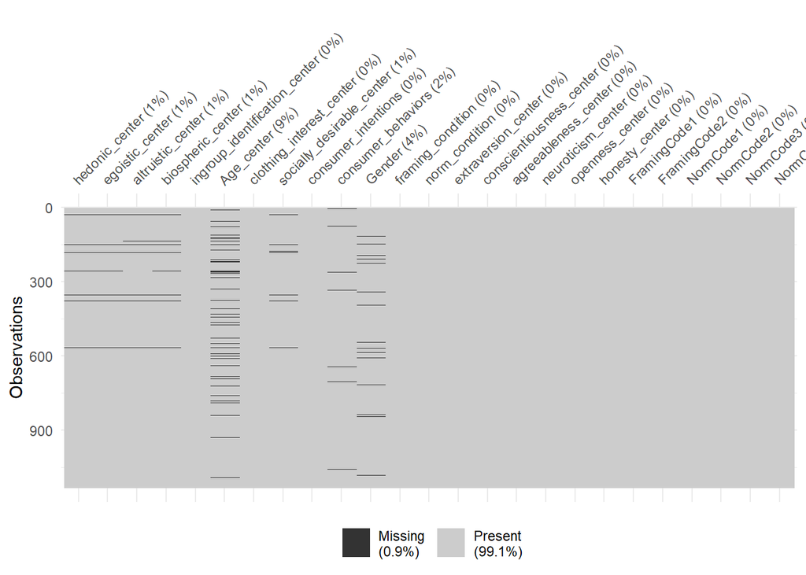

```r
data_R_alt %>%
  vis_miss()
```

```r
sum(is.na(data_R_alt$extraversion_center))
```

```
## [1] 2
```

```r
sum(is.na(data_R_alt$agreeableness_center))
```

```
## [1] 2
```

```r
sum(is.na(data_R_alt$openness_center))
```

```
## [1] 2
```

```r
sum(is.na(data_R_alt$conscientiousness_center))
```

```
## [1] 2
```

```r
sum(is.na(data_R_alt$neuroticism_center))
```

```
## [1] 2
```

```r
sum(is.na(data_R_alt$honesty_center))
```

```
## [1] 2
```

Variables with NO missing data:

- ingroup_identification_center
- clothing_interest_center
- consumer_intentions
- framing_condition
- norm_condition

Adding interaction terms:

Imputation model:

```r
set.seed(114950518)
```

```r
names(data_R_alt)
```

```
##   [1] "hedonic_center"                   "egoistic_center"
##   [3] "altruistic_center"                "biospheric_center"
##   [5] "ingroup_identification_center"    "Age_center"
##   [7] "clothing_interest_center"         "socially_desirable_center"
##   [9] "consumer_intentions"              "consumer_behaviors"
##  [11] "Gender"                           "framing_condition"
##  [13] "norm_condition"                   "extraversion_center"
##  [15] "conscientiousness_center"         "agreeableness_center"
##  [17] "neuroticism_center"               "openness_center"
##  [19] "honesty_center"                   "FramingCode1"
##  [21] "FramingCode2"                     "NormCode1"
##  [23] "NormCode2"                        "NormCode3"
##  [25] "NormCode4"                        "framing1Xbiospheric"
##  [27] "framing2Xbiospheric"              "norm1Xbiospheric"
##  [29] "norm2Xbiospheric"                 "norm3Xbiospheric"
```

[output cut: 75 more lines]

Storing imputed data sets:

## Convert imputed data to `mice` compatible object

Convert `scmfcs` object to a `mids` object:

Running model:

## Pooled Regression Results

Using `mice` package:

```r
summary(pool(mod_mice)) %>%
  knitr::kable(digits = 3)
```

| term | estimate | std.error | statistic | df | p.value |
| --- | --- | --- | --- | --- | --- |
| (Intercept) | 4.331 | 0.061 | 70.421 | 607.050 | 0.000 |
| framing_conditionFrameCode1 | 0.041 | 0.082 | 0.508 | 943.310 | 0.612 |
| framing_conditionFrameCode2 | 0.154 | 0.070 | 2.199 | 934.232 | 0.028 |
| norm_condition1 | -0.003 | 0.051 | -0.053 | 941.672 | 0.958 |
| norm_condition2 | 0.039 | 0.030 | 1.304 | 942.331 | 0.193 |
| norm_condition3 | -0.042 | 0.022 | -1.919 | 939.781 | 0.055 |
| norm_condition4 | -0.011 | 0.017 | -0.627 | 945.771 | 0.531 |
| biospheric_center | 0.255 | 0.048 | 5.341 | 882.551 | 0.000 |
| altruistic_center | 0.072 | 0.064 | 1.128 | 914.479 | 0.260 |
| egoistic_center | -0.218 | 0.045 | -4.829 | 917.010 | 0.000 |
| hedonic_center | -0.106 | 0.055 | -1.914 | 694.185 | 0.056 |
| ingroup_identification_center | 0.049 | 0.035 | 1.401 | 943.185 | 0.161 |
| extraversion_center | -0.050 | 0.058 | -0.861 | 912.309 | 0.389 |
| conscientiousness_center | -0.065 | 0.063 | -1.029 | 927.586 | 0.304 |
| agreeableness_center | 0.106 | 0.077 | 1.379 | 942.361 | 0.168 |
| neuroticism_center | 0.164 | 0.058 | 2.813 | 867.655 | 0.005 |
| openness_center | 0.418 | 0.063 | 6.687 | 944.685 | 0.000 |
| honesty_center | -0.124 | 0.056 | -2.220 | 913.877 | 0.027 |
| socially_desirable_center | -0.029 | 0.061 | -0.468 | 913.595 | 0.640 |
| clothing_interest_center | -0.051 | 0.046 | -1.086 | 933.501 | 0.278 |
| Gender1 | 0.127 | 0.084 | 1.503 | 373.427 | 0.134 |
| Age_center | -0.049 | 0.019 | -2.592 | 303.842 | 0.010 |
| framing_conditionFrameCode1:norm_condition1 | 0.137 | 0.124 | 1.102 | 942.691 | 0.271 |
| framing_conditionFrameCode2:norm_condition1 | -0.136 | 0.109 | -1.245 | 941.187 | 0.213 |
| framing_conditionFrameCode1:norm_condition2 | 0.001 | 0.075 | 0.020 | 935.422 | 0.984 |
| framing_conditionFrameCode2:norm_condition2 | -0.049 | 0.063 | -0.782 | 946.454 | 0.434 |
| framing_conditionFrameCode1:norm_condition3 | 0.011 | 0.052 | 0.213 | 941.559 | 0.831 |
| framing_conditionFrameCode2:norm_condition3 | 0.008 | 0.047 | 0.162 | 940.136 | 0.872 |
| framing_conditionFrameCode1:norm_condition4 | 0.031 | 0.043 | 0.734 | 944.125 | 0.463 |
| framing_conditionFrameCode2:norm_condition4 | -0.020 | 0.034 | -0.588 | 942.687 | 0.557 |

[output cut: 154 more lines]

# Simple Effects

## Personality Interactions

### Extraversion

First, relationship between extraversion & consumer intentions for each norm condition:

```r
emtrends(mod_mice, ~norm_condition, var = "extraversion_center", adjust = "none")
```

```
##  norm_condition   extraversion_center.trend    SE  df lower.CL upper.CL
##  control_norm                       -0.0492 0.112 949   -0.270    0.171
##  descriptive_norm                   -0.0853 0.136 949   -0.352    0.181
##  convention_norm                    -0.1846 0.119 949   -0.418    0.049
##  social_norm                         0.1678 0.126 949   -0.080    0.416
##  moral_norm                         -0.0978 0.142 949   -0.377    0.181
##
## Results are averaged over the levels of: framing_condition, Gender
## Confidence level used: 0.95
```

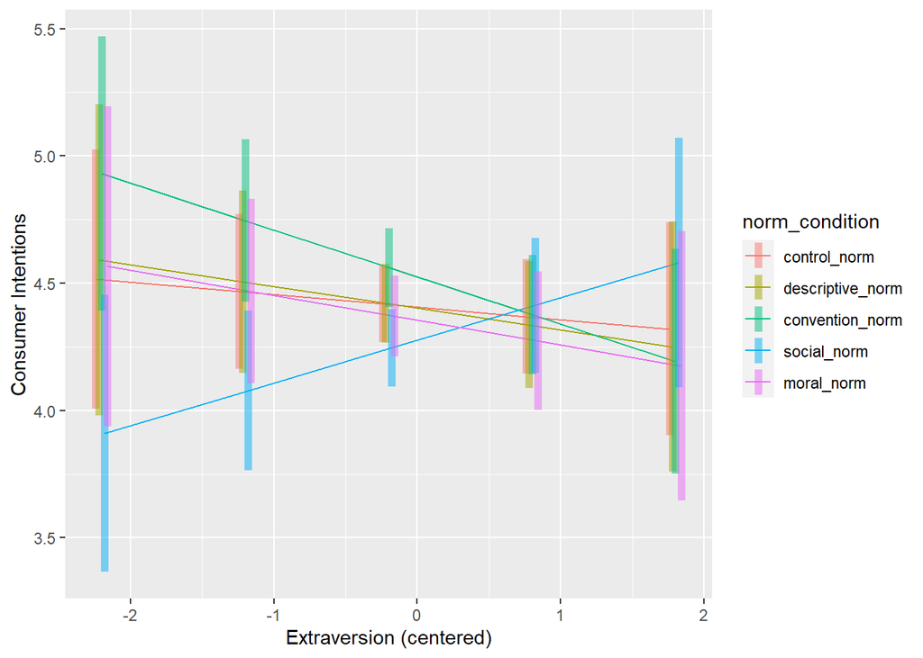

```r
# On a single graph
at_list <- list(extraversion_center = seq(-2.2, 2, by = 1))

emmip(mod_mice, norm_condition ~ extraversion_center, at = at_list, CIs = TRUE, xlab = "Extraversion (centered)", ylab = "Consumer Intentions")
```

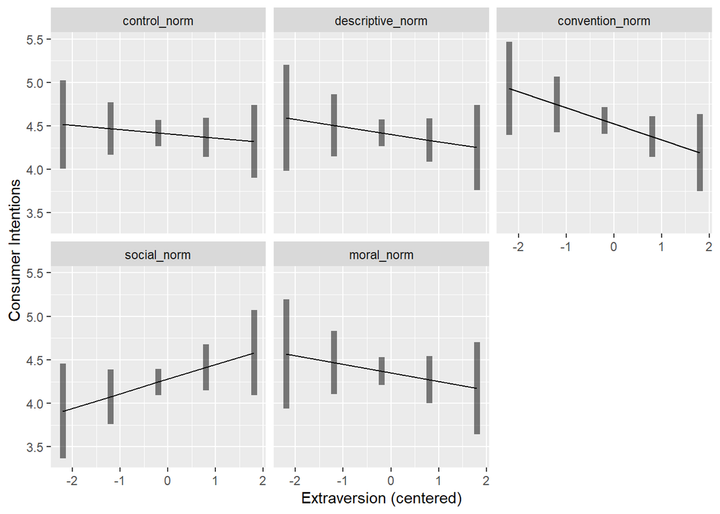

```r
# Separate graph for each norm
emmip(mod_mice, ~ extraversion_center | norm_condition, at = at_list, CIs = TRUE, xlab = "Extraversion (centered)", ylab = "Consumer Intentions")
```

Is the slope of the relationship between extraversion & consumer intentions stronger in any one of the norm conditions compared to the others?

```r
emtrends(mod_mice, pairwise~norm_condition, var = "extraversion_center", adjust = "none")
```

```
## $emtrends
##  norm_condition   extraversion_center.trend    SE  df lower.CL upper.CL
##  control_norm                       -0.0492 0.112 949   -0.270    0.171
##  descriptive_norm                   -0.0853 0.136 949   -0.352    0.181
##  convention_norm                    -0.1846 0.119 949   -0.418    0.049
##  social_norm                         0.1678 0.126 949   -0.080    0.416
##  moral_norm                         -0.0978 0.142 949   -0.377    0.181
##
## Results are averaged over the levels of: framing_condition, Gender
## Confidence level used: 0.95
##
## $contrasts
##  contrast                           estimate    SE  df t.ratio p.value
##  control_norm - descriptive_norm      0.0360 0.176 949   0.205  0.8379
##  control_norm - convention_norm       0.1354 0.163 949   0.831  0.4061
##  control_norm - social_norm          -0.2170 0.169 949  -1.288  0.1982
##  control_norm - moral_norm            0.0485 0.181 949   0.268  0.7887
##  descriptive_norm - convention_norm   0.0994 0.180 949   0.553  0.5802
##  descriptive_norm - social_norm      -0.2531 0.185 949  -1.370  0.1711
##  descriptive_norm - moral_norm        0.0125 0.196 949   0.064  0.9491
##  convention_norm - social_norm       -0.3524 0.173 949  -2.041  0.0415
##  convention_norm - moral_norm        -0.0869 0.185 949  -0.471  0.6380
##  social_norm - moral_norm             0.2656 0.190 949   1.399  0.1620
##
## Results are averaged over the levels of: framing_condition, Gender
```

Second, relationship between extraversion & consumer intentions for each framing condition:

```r
emtrends(mod_mice, ~framing_condition, var = "extraversion_center", adjust = "none")
```

```
##  framing_condition extraversion_center.trend     SE  df lower.CL upper.CL
##  control_framing                      0.0280 0.1002 949   -0.169   0.2246
##  pro_env_framing                     -0.1452 0.0996 949   -0.341   0.0502
##  self_enh_framing                    -0.0323 0.0972 949   -0.223   0.1584
##
## Results are averaged over the levels of: norm_condition, Gender
## Confidence level used: 0.95
```

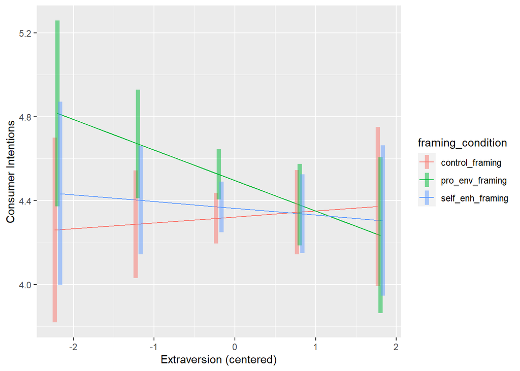

```r
# On a single graph
at_list <- list(extraversion_center = seq(-2.2, 2, by = 1))

emmip(mod_mice, framing_condition ~ extraversion_center, at = at_list, CIs = TRUE, xlab = "Extraversion (centered)", ylab = "Consumer Intentions")
```

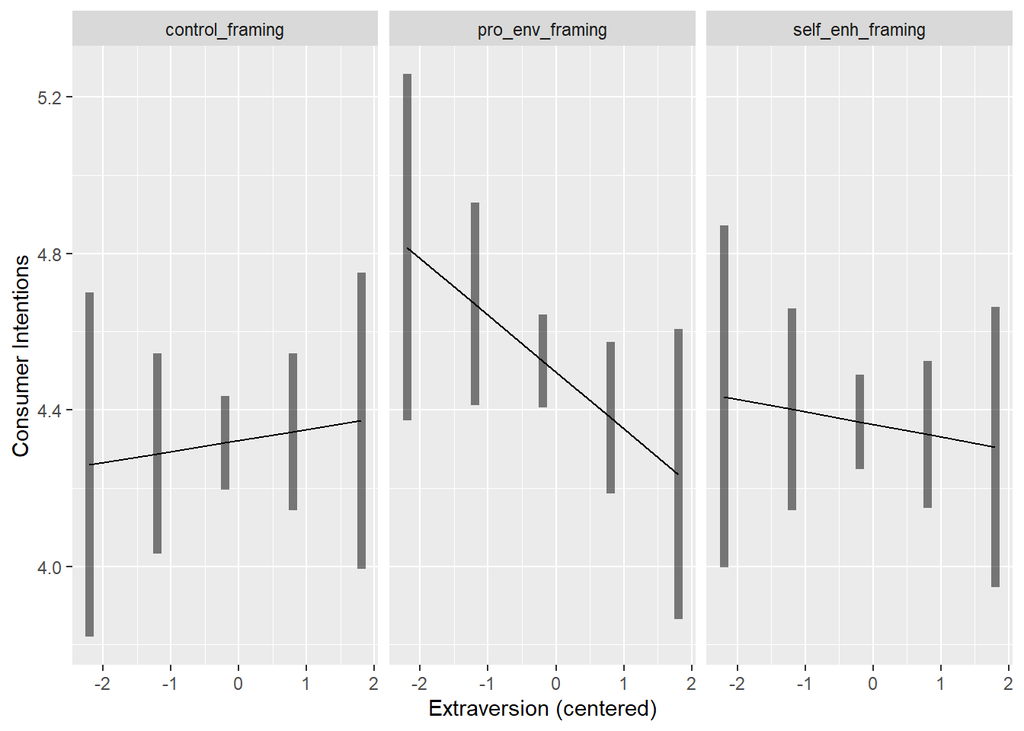

```r
# Separate graph for each norm
emmip(mod_mice, ~ extraversion_center | framing_condition, at = at_list, CIs = TRUE, xlab = "Extraversion (centered)", ylab = "Consumer Intentions")
```

Is the slope of the relationship between extraversion & consumer intentions stronger in any one of the framing conditions compared to the others?

```r
emtrends(mod_mice, pairwise~framing_condition, var = "extraversion_center", adjust = "none")
```

```
## $emtrends
##  framing_condition extraversion_center.trend     SE  df lower.CL upper.CL
##  control_framing                      0.0280 0.1002 949   -0.169   0.2246
##  pro_env_framing                     -0.1452 0.0996 949   -0.341   0.0502
##  self_enh_framing                    -0.0323 0.0972 949   -0.223   0.1584
##
## Results are averaged over the levels of: norm_condition, Gender
## Confidence level used: 0.95
##
## $contrasts
##  contrast                           estimate    SE  df t.ratio p.value
##  control_framing - pro_env_framing    0.1732 0.141 949   1.232  0.2181
##  control_framing - self_enh_framing   0.0604 0.139 949   0.436  0.6631
##  pro_env_framing - self_enh_framing  -0.1128 0.138 949  -0.816  0.4148
##
## Results are averaged over the levels of: norm_condition, Gender
```

Third, interaction between extraversion, framing, & norm condition:

```r
emtrends(mod_mice, ~norm_condition | framing_condition, var = "extraversion_center", adjust = "none")
```

```
## framing_condition = control_framing:
##  norm_condition   extraversion_center.trend    SE  df lower.CL upper.CL
##  control_norm                       0.40834 0.209 949  -0.0024  0.81909
##  descriptive_norm                   0.02502 0.253 949  -0.4718  0.52185
##  convention_norm                   -0.13850 0.220 949  -0.5710  0.29401
##  social_norm                       -0.05628 0.188 949  -0.4261  0.31350
##  moral_norm                        -0.09844 0.241 949  -0.5711  0.37424
##
## framing_condition = pro_env_framing:
##  norm_condition   extraversion_center.trend    SE  df lower.CL upper.CL
##  control_norm                      -0.26360 0.189 949  -0.6342  0.10701
##  descriptive_norm                  -0.36844 0.224 949  -0.8090  0.07207
##  convention_norm                   -0.00593 0.188 949  -0.3755  0.36368
##  social_norm                        0.02420 0.250 949  -0.4661  0.51451
##  moral_norm                        -0.11211 0.249 949  -0.6009  0.37666
##
## framing_condition = self_enh_framing:
##  norm_condition   extraversion_center.trend    SE  df lower.CL upper.CL
##  control_norm                      -0.29247 0.184 949  -0.6529  0.06793
##  descriptive_norm                   0.08762 0.224 949  -0.3523  0.52754
##  convention_norm                   -0.40951 0.207 949  -0.8164 -0.00257
##  social_norm                        0.53545 0.212 949   0.1188  0.95208
##  moral_norm                        -0.08276 0.248 949  -0.5687  0.40319
##
## Results are averaged over the levels of: Gender
## Confidence level used: 0.95
```

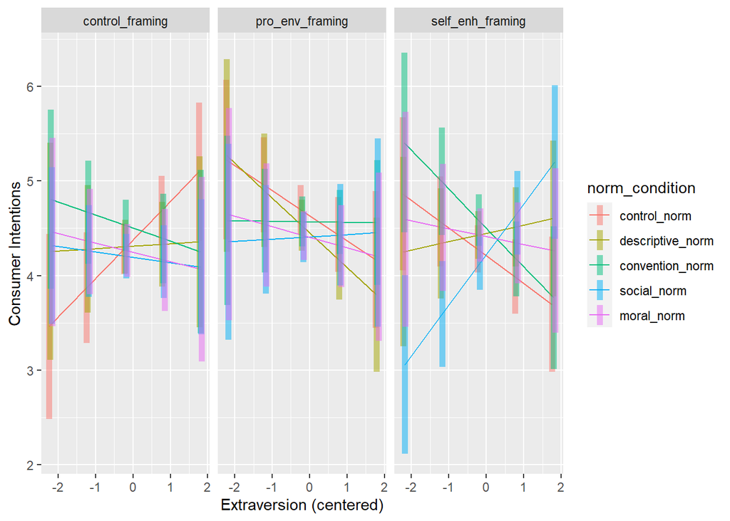

```r
# Separate graph for each framing condition
at_list <- list(extraversion_center = seq(-2.2, 2, by = 1))

emmip(mod_mice, norm_condition ~ extraversion_center | framing_condition, at = at_list, CIs = TRUE, xlab = "Extraversion (centered)", ylab = "Consumer Intentions")
```

### Agreeableness

First, relationship between agreeableness & consumer intentions for each norm condition:

```r
emtrends(mod_mice, ~norm_condition, var = "agreeableness_center", adjust = "none")
```

```
##  norm_condition   agreeableness_center.trend    SE  df lower.CL upper.CL
##  control_norm                         0.0641 0.164 949  -0.2579    0.386
##  descriptive_norm                     0.1154 0.180 949  -0.2380    0.469
##  convention_norm                      0.3228 0.179 949  -0.0287    0.674
##  social_norm                         -0.0095 0.174 949  -0.3502    0.331
##  moral_norm                           0.0369 0.156 949  -0.2697    0.343
##
## Results are averaged over the levels of: framing_condition, Gender
## Confidence level used: 0.95
```

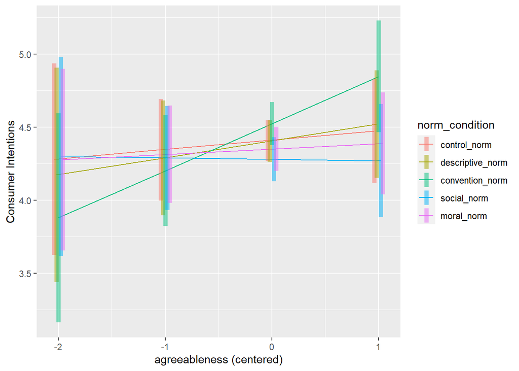

```r
# On a single graph
at_list <- list(agreeableness_center = seq(-2, 1.4, by = 1))

emmip(mod_mice, norm_condition ~ agreeableness_center, at = at_list, CIs = TRUE, xlab = "agreeableness (centered)", ylab = "Consumer Intentions")
```

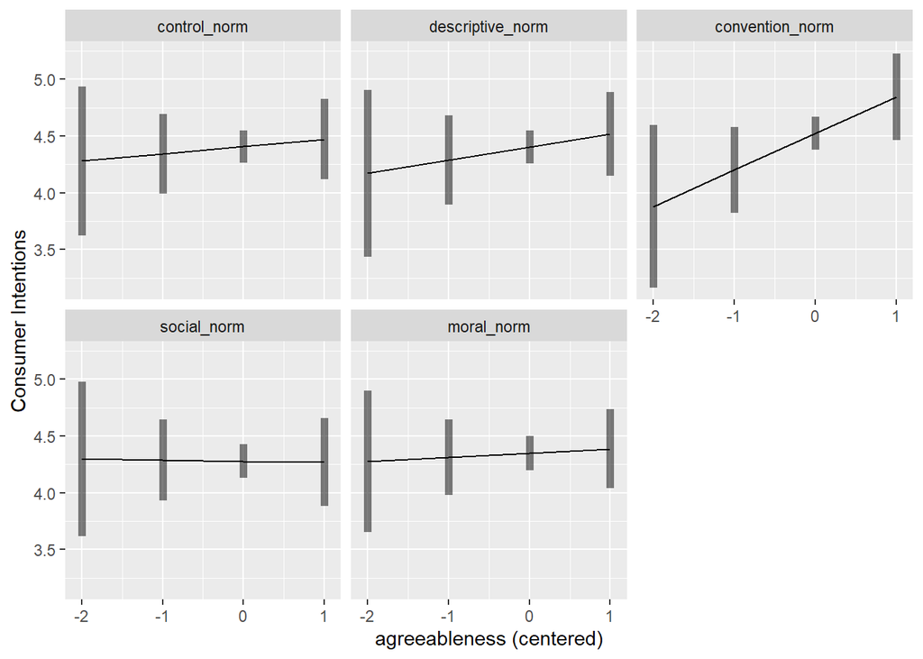

```r
# Separate graph for each norm
emmip(mod_mice, ~ agreeableness_center | norm_condition, at = at_list, CIs = TRUE, xlab = "agreeableness (centered)", ylab = "Consumer Intentions")
```

Is the slope of the relationship between agreeableness & consumer intentions stronger in any one of the norm conditions compared to the others?

```r
emtrends(mod_mice, pairwise~norm_condition, var = "agreeableness_center", adjust = "none")
```

```
## $emtrends
##  norm_condition   agreeableness_center.trend    SE  df lower.CL upper.CL
##  control_norm                         0.0641 0.164 949  -0.2579    0.386
##  descriptive_norm                     0.1154 0.180 949  -0.2380    0.469
##  convention_norm                      0.3228 0.179 949  -0.0287    0.674
##  social_norm                         -0.0095 0.174 949  -0.3502    0.331
##  moral_norm                           0.0369 0.156 949  -0.2697    0.343
##
## Results are averaged over the levels of: framing_condition, Gender
## Confidence level used: 0.95
##
## $contrasts
##  contrast                           estimate    SE  df t.ratio p.value
##  control_norm - descriptive_norm     -0.0513 0.243 949  -0.211  0.8327
##  control_norm - convention_norm      -0.2587 0.243 949  -1.067  0.2864
##  control_norm - social_norm           0.0736 0.239 949   0.308  0.7579
##  control_norm - moral_norm            0.0272 0.226 949   0.120  0.9044
##  descriptive_norm - convention_norm  -0.2074 0.254 949  -0.817  0.4143
##  descriptive_norm - social_norm       0.1249 0.250 949   0.499  0.6177
##  descriptive_norm - moral_norm        0.0785 0.238 949   0.329  0.7420
##  convention_norm - social_norm        0.3323 0.249 949   1.334  0.1826
##  convention_norm - moral_norm         0.2859 0.237 949   1.207  0.2277
##  social_norm - moral_norm            -0.0464 0.232 949  -0.200  0.8417
##
## Results are averaged over the levels of: framing_condition, Gender
```

Second, relationship between agreeableness & consumer intentions for each framing condition:

```r
emtrends(mod_mice, ~framing_condition, var = "agreeableness_center", adjust = "none")
```

```
##  framing_condition agreeableness_center.trend    SE  df lower.CL upper.CL
##  control_framing                       0.1690 0.128 949  -0.0826    0.421
##  pro_env_framing                      -0.0344 0.137 949  -0.3036    0.235
##  self_enh_framing                      0.1832 0.132 949  -0.0753    0.442
##
## Results are averaged over the levels of: norm_condition, Gender
## Confidence level used: 0.95
```

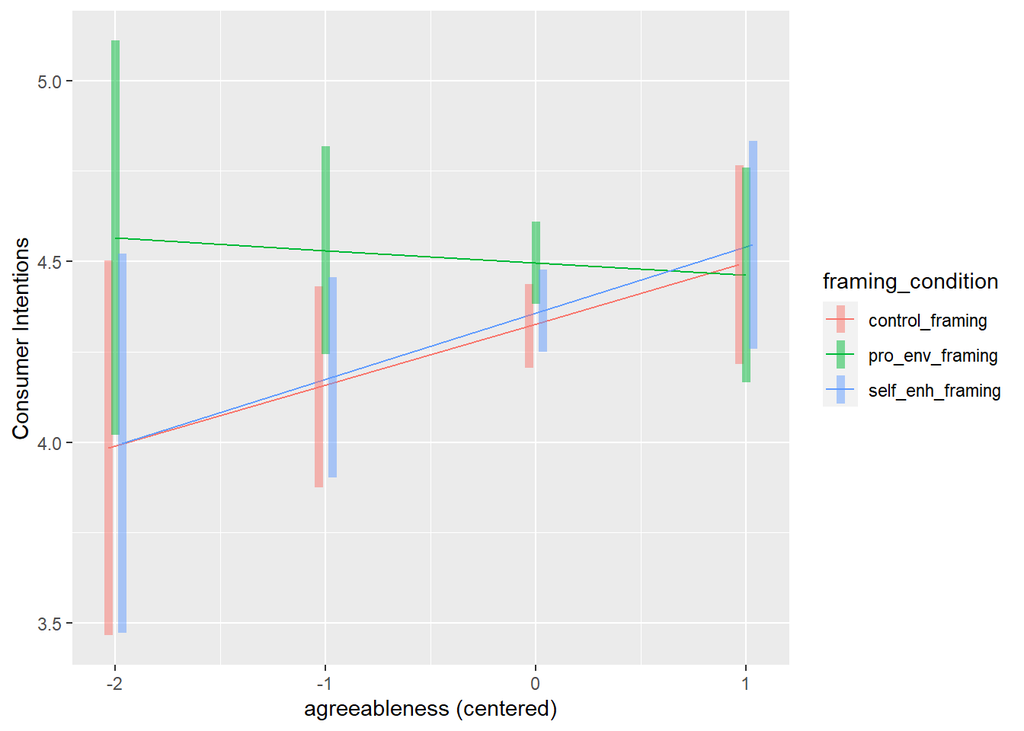

```r
# On a single graph
at_list <- list(agreeableness_center = seq(-2, 1.4, by = 1))

emmip(mod_mice, framing_condition ~ agreeableness_center, at = at_list, CIs = TRUE, xlab = "agreeableness (centered)", ylab = "Consumer Intentions")
```

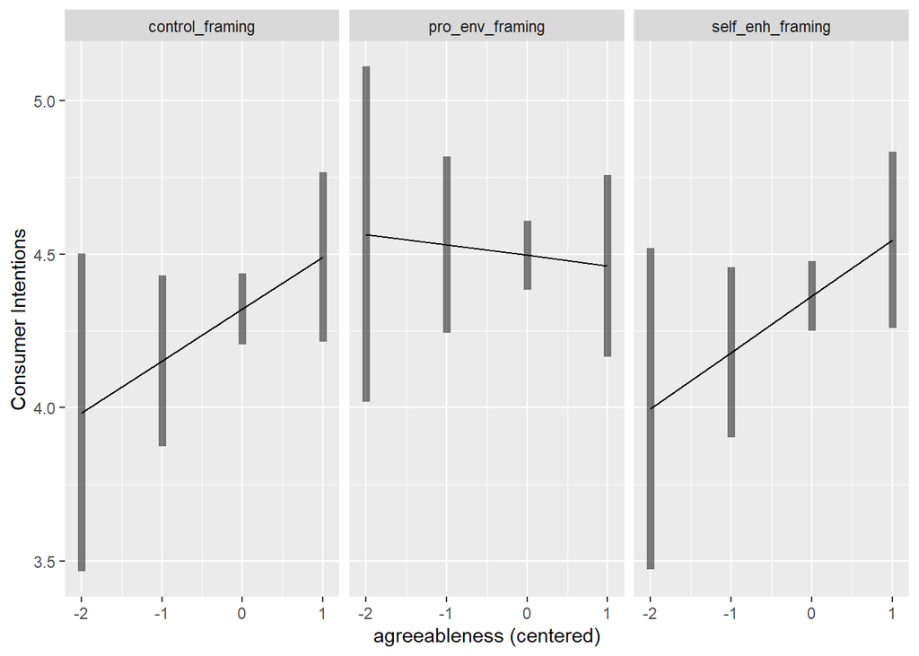

```r
# Separate graph for each norm
emmip(mod_mice, ~ agreeableness_center | framing_condition, at = at_list, CIs = TRUE, xlab = "agreeableness (centered)", ylab = "Consumer Intentions")
```

Is the slope of the relationship between agreeableness & consumer intentions stronger in any one of the framing conditions compared to the others?

```r
emtrends(mod_mice, pairwise~framing_condition, var = "agreeableness_center", adjust = "none")
```

```
## $emtrends
##  framing_condition agreeableness_center.trend    SE  df lower.CL upper.CL
##  control_framing                       0.1690 0.128 949  -0.0826    0.421
##  pro_env_framing                      -0.0344 0.137 949  -0.3036    0.235
##  self_enh_framing                      0.1832 0.132 949  -0.0753    0.442
##
## Results are averaged over the levels of: norm_condition, Gender
## Confidence level used: 0.95
##
## $contrasts
##  contrast                           estimate    SE  df t.ratio p.value
##  control_framing - pro_env_framing    0.2034 0.187 949   1.086  0.2778
##  control_framing - self_enh_framing  -0.0142 0.183 949  -0.077  0.9384
##  pro_env_framing - self_enh_framing  -0.2176 0.190 949  -1.148  0.2515
##
## Results are averaged over the levels of: norm_condition, Gender
```

Third, interaction between agreeableness, framing, & norm condition:

```r
emtrends(mod_mice, ~norm_condition | framing_condition, var = "agreeableness_center", adjust = "none")
```

```
## framing_condition = control_framing:
##  norm_condition   agreeableness_center.trend    SE  df lower.CL upper.CL
##  control_norm                         0.0703 0.275 949  -0.4699    0.610
##  descriptive_norm                     0.2462 0.290 949  -0.3231    0.816
##  convention_norm                      0.4934 0.350 949  -0.1936    1.180
##  social_norm                          0.4250 0.251 949  -0.0668    0.917
##  moral_norm                          -0.3897 0.258 949  -0.8967    0.117
##
## framing_condition = pro_env_framing:
##  norm_condition   agreeableness_center.trend    SE  df lower.CL upper.CL
##  control_norm                         0.2309 0.304 949  -0.3661    0.828
##  descriptive_norm                    -0.1612 0.341 949  -0.8305    0.508
##  convention_norm                     -0.1362 0.280 949  -0.6853    0.413
##  social_norm                         -0.3473 0.319 949  -0.9733    0.279
##  moral_norm                           0.2419 0.278 949  -0.3044    0.788
##
## framing_condition = self_enh_framing:
##  norm_condition   agreeableness_center.trend    SE  df lower.CL upper.CL
##  control_norm                        -0.1089 0.273 949  -0.6443    0.427
##  descriptive_norm                     0.2614 0.302 949  -0.3303    0.853
##  convention_norm                      0.6113 0.295 949   0.0330    1.190
##  social_norm                         -0.1062 0.326 949  -0.7453    0.533
##  moral_norm                           0.2586 0.272 949  -0.2750    0.792
##
## Results are averaged over the levels of: Gender
## Confidence level used: 0.95
```

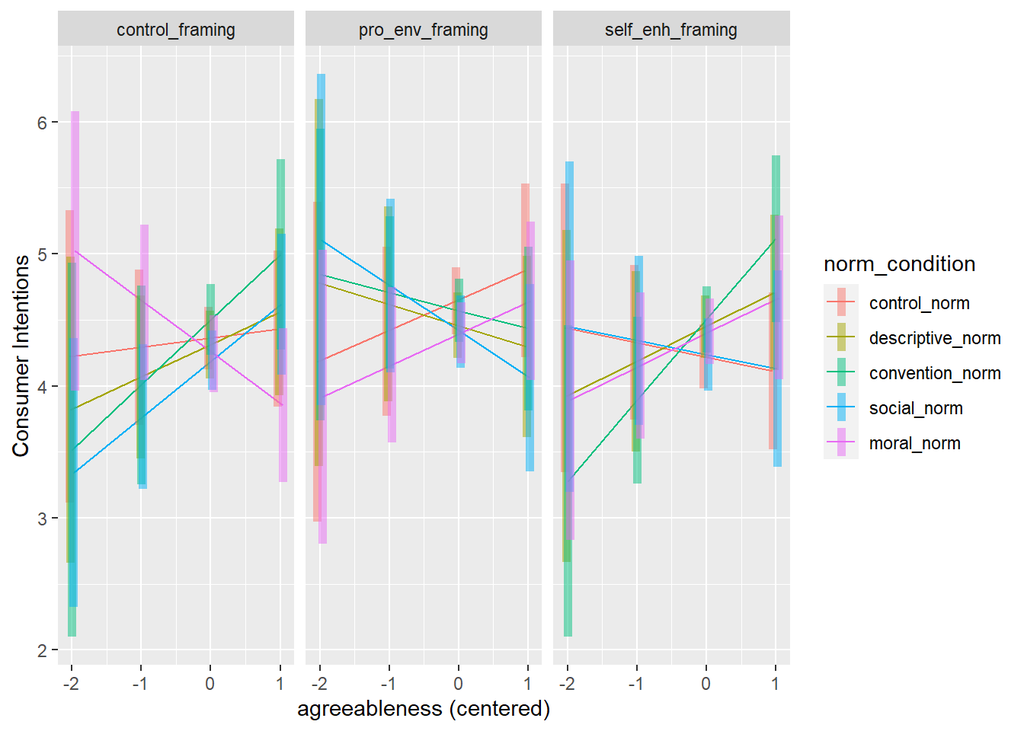

```r
# Separate graph for each framing condition
at_list <- list(agreeableness_center = seq(-2, 1.4, by = 1))

emmip(mod_mice, norm_condition ~ agreeableness_center | framing_condition, at = at_list, CIs = TRUE, xlab = "agreeableness (centered)", ylab = "Consumer Intentions")
```

### Openness

First, relationship between openness & consumer intentions for each norm condition:

```r
emtrends(mod_mice, ~norm_condition, var = "openness_center", adjust = "none")
```

```
##  norm_condition   openness_center.trend    SE  df lower.CL upper.CL
##  control_norm                     0.351 0.136 949   0.0845    0.617
##  descriptive_norm                 0.215 0.135 949  -0.0504    0.480
##  convention_norm                  0.436 0.135 949   0.1709    0.702
##  social_norm                      0.531 0.147 949   0.2424    0.819
##  moral_norm                       0.559 0.141 949   0.2814    0.836
##
## Results are averaged over the levels of: framing_condition, Gender
## Confidence level used: 0.95
```

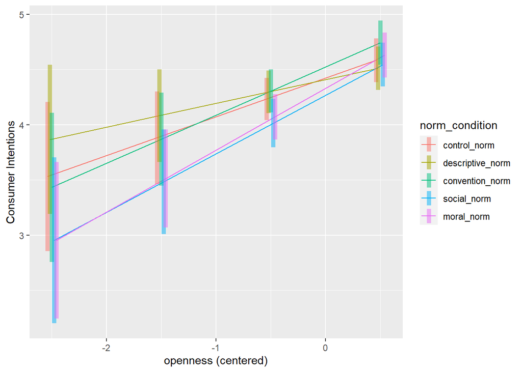

```r
# On a single graph
at_list <- list(openness_center = seq(-2.5, 1.4, by = 1))

emmip(mod_mice, norm_condition ~ openness_center, at = at_list, CIs = TRUE, xlab = "openness (centered)", ylab = "Consumer Intentions")
```

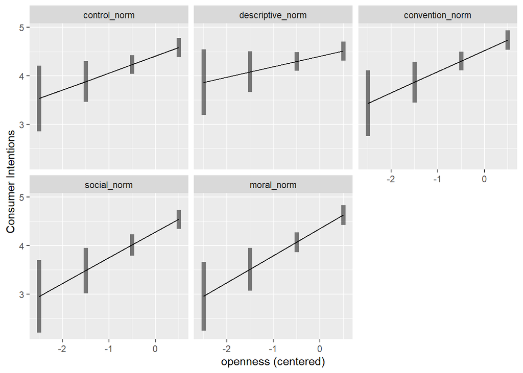

```r
# Separate graph for each norm
emmip(mod_mice, ~ openness_center | norm_condition, at = at_list, CIs = TRUE, xlab = "openness (centered)", ylab = "Consumer Intentions")
```

Is the slope of the relationship between openness & consumer intentions stronger in any one of the norm conditions compared to the others?

```r
emtrends(mod_mice, pairwise~norm_condition, var = "openness_center", adjust = "none")
```

```
## $emtrends
##  norm_condition   openness_center.trend    SE  df lower.CL upper.CL
##  control_norm                     0.351 0.136 949   0.0845    0.617
##  descriptive_norm                 0.215 0.135 949  -0.0504    0.480
##  convention_norm                  0.436 0.135 949   0.1709    0.702
##  social_norm                      0.531 0.147 949   0.2424    0.819
##  moral_norm                       0.559 0.141 949   0.2814    0.836
##
## Results are averaged over the levels of: framing_condition, Gender
## Confidence level used: 0.95
##
## $contrasts
##  contrast                           estimate    SE  df t.ratio p.value
##  control_norm - descriptive_norm      0.1359 0.191 949   0.710  0.4778
##  control_norm - convention_norm      -0.0855 0.191 949  -0.447  0.6552
##  control_norm - social_norm          -0.1800 0.199 949  -0.904  0.3660
##  control_norm - moral_norm           -0.2080 0.196 949  -1.063  0.2880
##  descriptive_norm - convention_norm  -0.2214 0.191 949  -1.161  0.2460
##  descriptive_norm - social_norm      -0.3160 0.199 949  -1.587  0.1128
##  descriptive_norm - moral_norm       -0.3439 0.196 949  -1.759  0.0789
##  convention_norm - social_norm       -0.0946 0.200 949  -0.474  0.6358
##  convention_norm - moral_norm        -0.1226 0.196 949  -0.626  0.5316
##  social_norm - moral_norm            -0.0280 0.204 949  -0.137  0.8907
##
## Results are averaged over the levels of: framing_condition, Gender
```

Second, relationship between openness & consumer intentions for each framing condition:

```r
emtrends(mod_mice, ~framing_condition, var = "openness_center", adjust = "none")
```

```
##  framing_condition openness_center.trend    SE  df lower.CL upper.CL
##  control_framing                   0.488 0.112 949    0.269    0.707
##  pro_env_framing                   0.458 0.105 949    0.252    0.663
##  self_enh_framing                  0.310 0.107 949    0.100    0.519
##
## Results are averaged over the levels of: norm_condition, Gender
## Confidence level used: 0.95
```

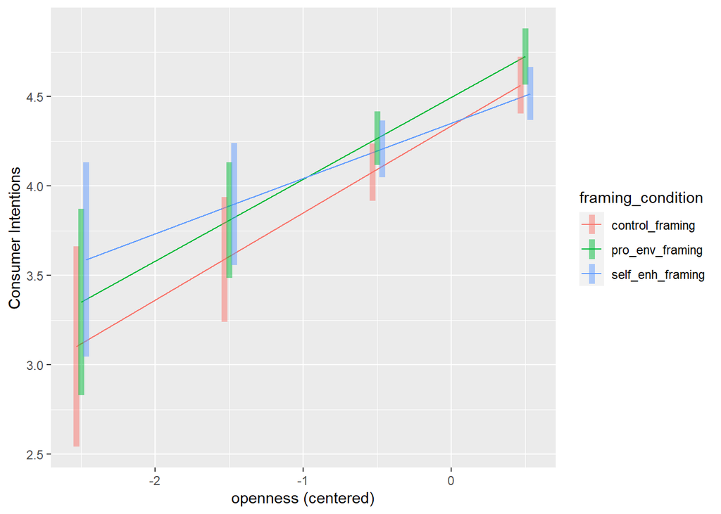

```r
# On a single graph
at_list <- list(openness_center = seq(-2.5, 1.4, by = 1))

emmip(mod_mice, framing_condition ~ openness_center, at = at_list, CIs = TRUE, xlab = "openness (centered)", ylab = "Consumer Intentions")
```

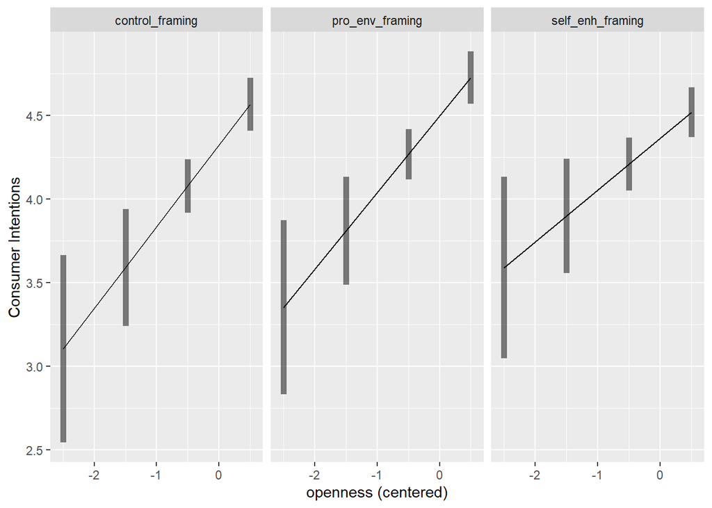

```r
# Separate graph for each norm
emmip(mod_mice, ~ openness_center | framing_condition, at = at_list, CIs = TRUE, xlab = "openness (centered)", ylab = "Consumer Intentions")
```

Is the slope of the relationship between openness & consumer intentions stronger in any one of the framing conditions compared to the others?

```r
emtrends(mod_mice, pairwise~framing_condition, var = "openness_center", adjust = "none")
```

```
## $emtrends
##  framing_condition openness_center.trend    SE  df lower.CL upper.CL
##  control_framing                   0.488 0.112 949    0.269    0.707
##  pro_env_framing                   0.458 0.105 949    0.252    0.663
##  self_enh_framing                  0.310 0.107 949    0.100    0.519
##
## Results are averaged over the levels of: norm_condition, Gender
## Confidence level used: 0.95
##
## $contrasts
##  contrast                           estimate    SE  df t.ratio p.value
##  control_framing - pro_env_framing    0.0301 0.153 949   0.197  0.8439
##  control_framing - self_enh_framing   0.1779 0.154 949   1.155  0.2486
##  pro_env_framing - self_enh_framing   0.1479 0.149 949   0.992  0.3214
##
## Results are averaged over the levels of: norm_condition, Gender
```

Third, interaction between openness, framing, & norm condition:

```r
emtrends(mod_mice, ~norm_condition | framing_condition, var = "openness_center", adjust = "none")
```

```
## framing_condition = control_framing:
##  norm_condition   openness_center.trend    SE  df  lower.CL upper.CL
##  control_norm                   -0.1484 0.222 949 -0.584339    0.288
##  descriptive_norm                0.2529 0.261 949 -0.259170    0.765
##  convention_norm                 0.6529 0.244 949  0.173756    1.132
##  social_norm                     1.0258 0.244 949  0.545989    1.506
##  moral_norm                      0.6553 0.268 949  0.129521    1.181
##
## framing_condition = pro_env_framing:
##  norm_condition   openness_center.trend    SE  df  lower.CL upper.CL
##  control_norm                    0.5130 0.261 949  0.000397    1.026
##  descriptive_norm                0.4565 0.229 949  0.007412    0.906
##  convention_norm                 0.4374 0.209 949  0.027927    0.847
##  social_norm                     0.3539 0.259 949 -0.154245    0.862
##  moral_norm                      0.5274 0.201 949  0.132923    0.922
##
## framing_condition = self_enh_framing:
##  norm_condition   openness_center.trend    SE  df  lower.CL upper.CL
##  control_norm                    0.6879 0.215 949  0.265222    1.111
##  descriptive_norm               -0.0645 0.206 949 -0.469581    0.341
##  convention_norm                 0.2186 0.248 949 -0.267811    0.705
##  social_norm                     0.2130 0.259 949 -0.296067    0.722
##  moral_norm                      0.4940 0.260 949 -0.017196    1.005
##
## Results are averaged over the levels of: Gender
## Confidence level used: 0.95
```

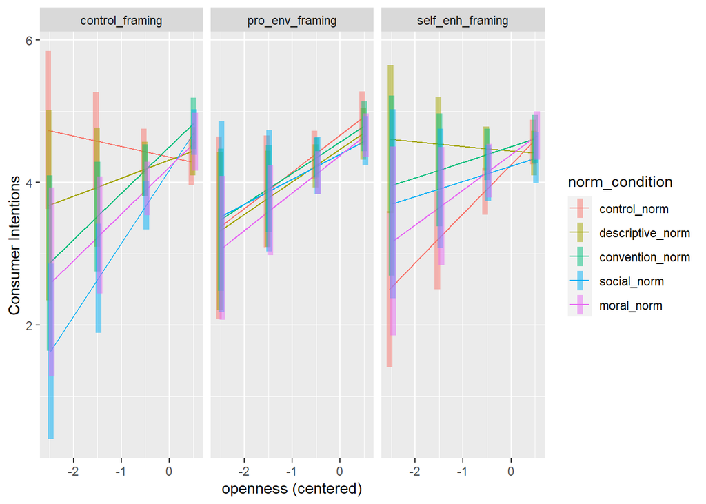

```r
# Separate graph for each framing condition
at_list <- list(openness_center = seq(-2.5, 1.4, by = 1))

emmip(mod_mice, norm_condition ~ openness_center | framing_condition, at = at_list, CIs = TRUE, xlab = "openness (centered)", ylab = "Consumer Intentions")
```

### Conscientiousness

First, relationship between conscientiousness & consumer intentions for each norm condition:

```r
emtrends(mod_mice, ~norm_condition, var = "conscientiousness_center", adjust = "none")
```

```
##  norm_condition   conscientiousness_center.trend    SE  df lower.CL upper.CL
##  control_norm                            -0.1808 0.144 949   -0.464    0.103
##  descriptive_norm                         0.0398 0.146 949   -0.247    0.326
##  convention_norm                          0.1569 0.132 949   -0.101    0.415
##  social_norm                             -0.4659 0.135 949   -0.730   -0.202
##  moral_norm                               0.1259 0.132 949   -0.133    0.384
##
## Results are averaged over the levels of: framing_condition, Gender
## Confidence level used: 0.95
```

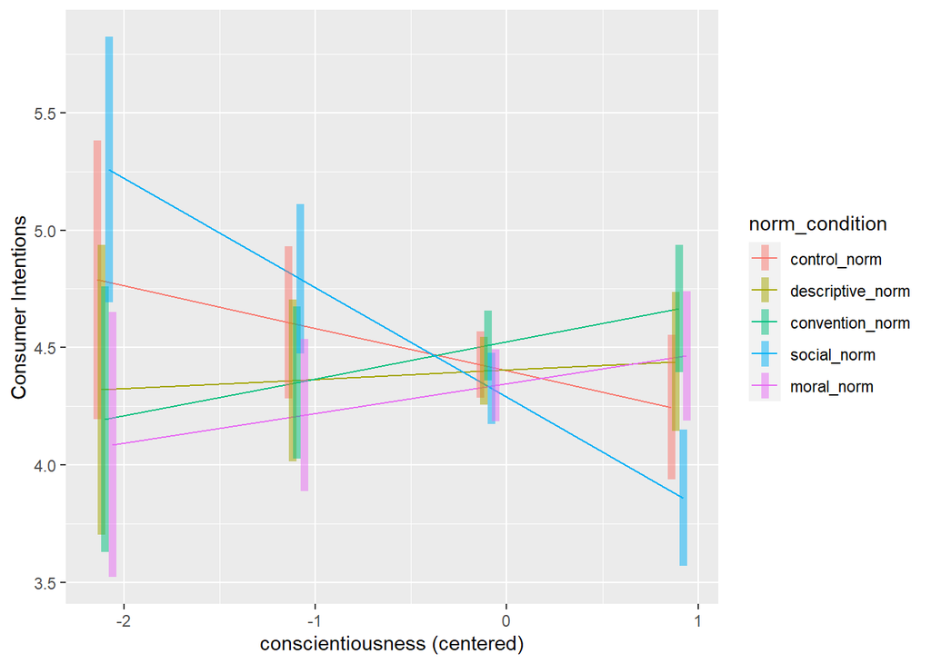

```r
# On a single graph
at_list <- list(conscientiousness_center = seq(-2.1, 1.7, by = 1))

emmip(mod_mice, norm_condition ~ conscientiousness_center, at = at_list, CIs = TRUE, xlab = "conscientiousness (centered)", ylab = "Consumer Intentions")
```

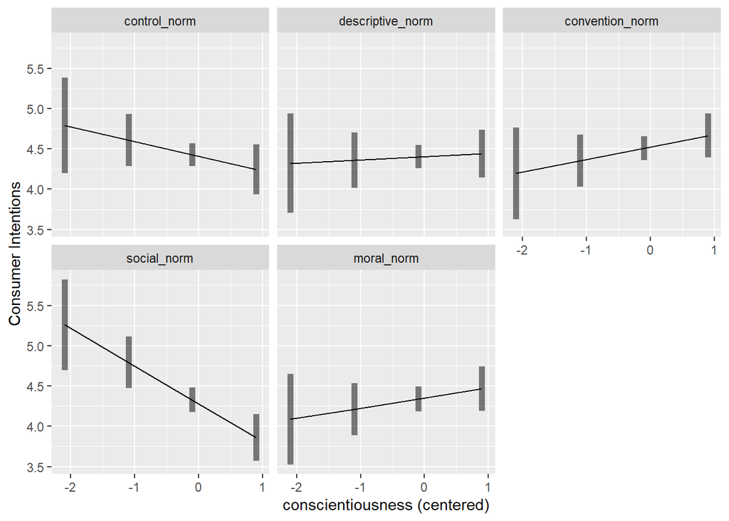

```r
# Separate graph for each norm
emmip(mod_mice, ~ conscientiousness_center | norm_condition, at = at_list, CIs = TRUE, xlab = "conscientiousness (centered)", ylab = "Consumer Intentions")
```

Is the slope of the relationship between conscientiousness & consumer intentions stronger in any one of the norm conditions compared to the others?

```r
emtrends(mod_mice, pairwise~norm_condition, var = "conscientiousness_center", adjust = "none")
```

```
## $emtrends
##  norm_condition   conscientiousness_center.trend    SE  df lower.CL upper.CL
##  control_norm                            -0.1808 0.144 949   -0.464    0.103
##  descriptive_norm                         0.0398 0.146 949   -0.247    0.326
##  convention_norm                          0.1569 0.132 949   -0.101    0.415
##  social_norm                             -0.4659 0.135 949   -0.730   -0.202
##  moral_norm                               0.1259 0.132 949   -0.133    0.384
##
## Results are averaged over the levels of: framing_condition, Gender
## Confidence level used: 0.95
##
## $contrasts
##  contrast                           estimate    SE  df t.ratio p.value
##  control_norm - descriptive_norm     -0.2205 0.205 949  -1.075  0.2827
##  control_norm - convention_norm      -0.3377 0.195 949  -1.735  0.0831
##  control_norm - social_norm           0.2852 0.196 949   1.453  0.1464
##  control_norm - moral_norm           -0.3066 0.194 949  -1.577  0.1152
##  descriptive_norm - convention_norm  -0.1171 0.196 949  -0.598  0.5501
##  descriptive_norm - social_norm       0.5057 0.198 949   2.556  0.0107
##  descriptive_norm - moral_norm       -0.0861 0.196 949  -0.439  0.6605
##  convention_norm - social_norm        0.6228 0.186 949   3.346  0.0009
##  convention_norm - moral_norm         0.0310 0.185 949   0.168  0.8666
##  social_norm - moral_norm            -0.5918 0.186 949  -3.185  0.0015
##
## Results are averaged over the levels of: framing_condition, Gender
```

Second, relationship between conscientiousness & consumer intentions for each framing condition:

```r
emtrends(mod_mice, ~framing_condition, var = "conscientiousness_center", adjust = "none")
```

```
##  framing_condition conscientiousness_center.trend    SE  df lower.CL upper.CL
##  control_framing                          -0.2949 0.110 949   -0.510  -0.0794
##  pro_env_framing                           0.0472 0.101 949   -0.152   0.2462
##  self_enh_framing                          0.0532 0.110 949   -0.163   0.2691
##
## Results are averaged over the levels of: norm_condition, Gender
## Confidence level used: 0.95
```

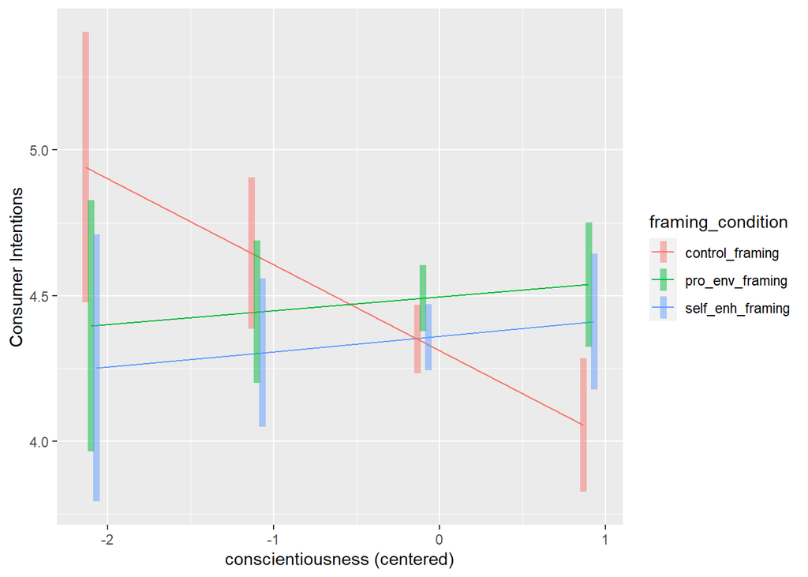

```r
# On a single graph
at_list <- list(conscientiousness_center = seq(-2.1, 1.7, by = 1))

emmip(mod_mice, framing_condition ~ conscientiousness_center, at = at_list, CIs = TRUE, xlab = "conscientiousness (centered)", ylab = "Consumer Intentions")
```

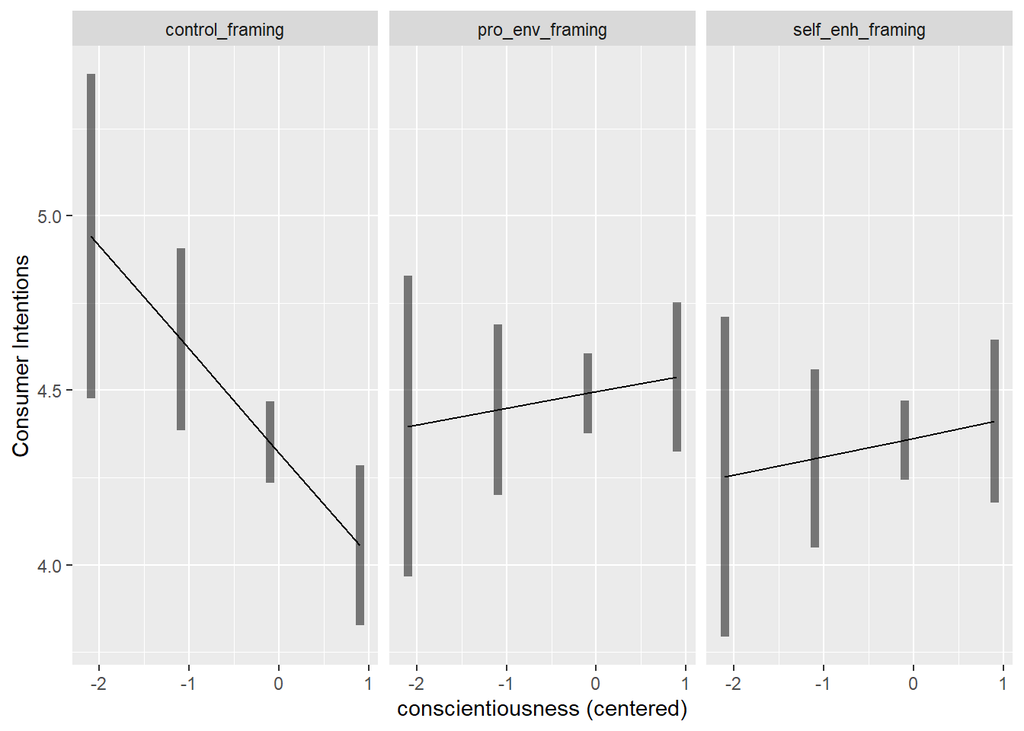

```r
# Separate graph for each norm
emmip(mod_mice, ~ conscientiousness_center | framing_condition, at = at_list, CIs = TRUE, xlab = "conscientiousness (centered)", ylab = "Consumer Intentions")
```

Is the slope of the relationship between conscientiousness & consumer intentions stronger in any one of the framing conditions compared to the others?

```r
emtrends(mod_mice, pairwise~framing_condition, var = "conscientiousness_center", adjust = "none")
```

```
## $emtrends
##  framing_condition conscientiousness_center.trend    SE  df lower.CL upper.CL
##  control_framing                          -0.2949 0.110 949   -0.510  -0.0794
##  pro_env_framing                           0.0472 0.101 949   -0.152   0.2462
##  self_enh_framing                          0.0532 0.110 949   -0.163   0.2691
##
## Results are averaged over the levels of: norm_condition, Gender
## Confidence level used: 0.95
##
## $contrasts
##  contrast                           estimate    SE  df t.ratio p.value
##  control_framing - pro_env_framing  -0.34213 0.148 949  -2.319  0.0206
##  control_framing - self_enh_framing -0.34812 0.154 949  -2.257  0.0242
##  pro_env_framing - self_enh_framing -0.00599 0.149 949  -0.040  0.9679
##
## Results are averaged over the levels of: norm_condition, Gender
```

Third, interaction between conscientiousness, framing, & norm condition:

```r
emtrends(mod_mice, ~norm_condition | framing_condition, var = "conscientiousness_center", adjust = "none")
```

```
## framing_condition = control_framing:
##  norm_condition   conscientiousness_center.trend    SE  df lower.CL upper.CL
##  control_norm                           -0.63296 0.281 949  -1.1854  -0.0805
##  descriptive_norm                        0.02416 0.261 949  -0.4882   0.5365
##  convention_norm                        -0.07112 0.238 949  -0.5375   0.3953
##  social_norm                            -0.54742 0.196 949  -0.9328  -0.1620
##  moral_norm                             -0.24725 0.233 949  -0.7038   0.2093
##
## framing_condition = pro_env_framing:
##  norm_condition   conscientiousness_center.trend    SE  df lower.CL upper.CL
##  control_norm                           -0.04577 0.220 949  -0.4778   0.3862
##  descriptive_norm                        0.09343 0.245 949  -0.3867   0.5735
##  convention_norm                         0.45439 0.226 949   0.0107   0.8980
##  social_norm                            -0.21486 0.218 949  -0.6434   0.2137
##  moral_norm                             -0.05113 0.212 949  -0.4662   0.3639
##
## framing_condition = self_enh_framing:
##  norm_condition   conscientiousness_center.trend    SE  df lower.CL upper.CL
##  control_norm                            0.13643 0.245 949  -0.3445   0.6173
##  descriptive_norm                        0.00173 0.253 949  -0.4948   0.4982
##  convention_norm                         0.08742 0.217 949  -0.3380   0.5129
##  social_norm                            -0.63552 0.270 949  -1.1659  -0.1051
##  moral_norm                              0.67595 0.239 949   0.2075   1.1444
##
## Results are averaged over the levels of: Gender
## Confidence level used: 0.95
```

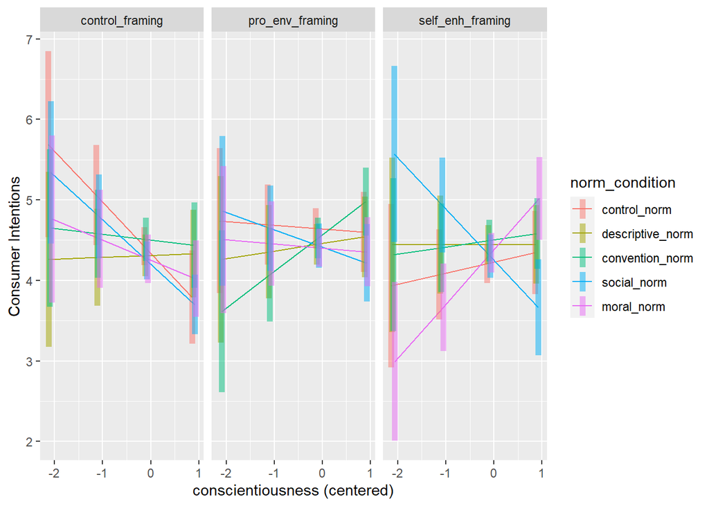

```r
# Separate graph for each framing condition
at_list <- list(conscientiousness_center = seq(-2.1, 1.7, by = 1))

emmip(mod_mice, norm_condition ~ conscientiousness_center | framing_condition, at = at_list, CIs = TRUE, xlab = "conscientiousness (centered)", ylab = "Consumer Intentions")
```

### Neuroticism

First, relationship between neuroticism & consumer intentions for each norm condition:

```r
emtrends(mod_mice, ~norm_condition, var = "neuroticism_center", adjust = "none")
```

```
##  norm_condition   neuroticism_center.trend    SE  df lower.CL upper.CL
##  control_norm                       0.1945 0.114 949 -0.02825    0.417
##  descriptive_norm                   0.0531 0.117 949 -0.17742    0.284
##  convention_norm                    0.3171 0.115 949  0.09102    0.543
##  social_norm                        0.0469 0.126 949 -0.20067    0.294
##  moral_norm                         0.2081 0.110 949 -0.00862    0.425
##
## Results are averaged over the levels of: framing_condition, Gender
## Confidence level used: 0.95
```

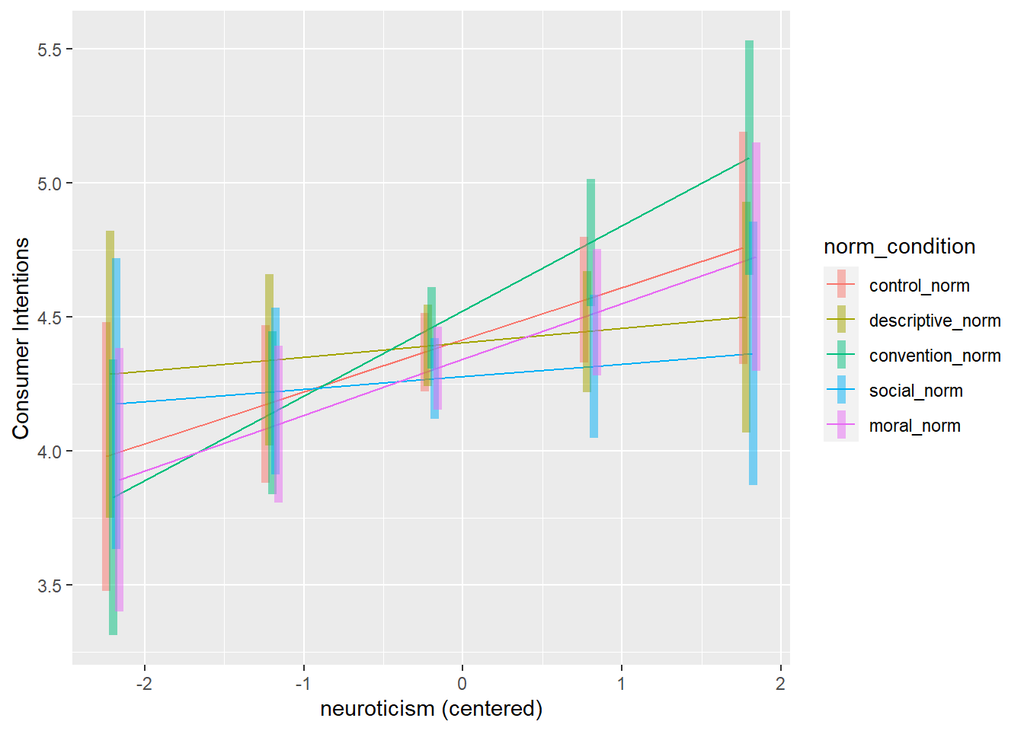

```r
# On a single graph
at_list <- list(neuroticism_center = seq(-2.2, 2.1, by = 1))

emmip(mod_mice, norm_condition ~ neuroticism_center, at = at_list, CIs = TRUE, xlab = "neuroticism (centered)", ylab = "Consumer Intentions")
```

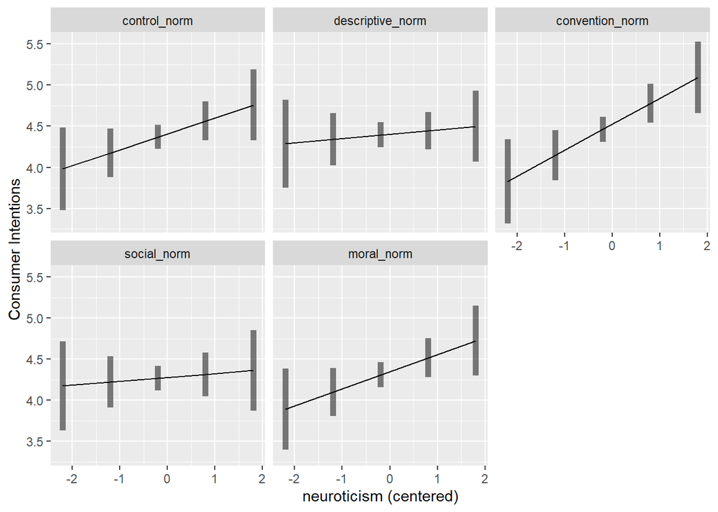

```r
# Separate graph for each norm
emmip(mod_mice, ~ neuroticism_center | norm_condition, at = at_list, CIs = TRUE, xlab = "neuroticism (centered)", ylab = "Consumer Intentions")
```

Is the slope of the relationship between neuroticism & consumer intentions stronger in any one of the norm conditions compared to the others?

```r
emtrends(mod_mice, pairwise~norm_condition, var = "neuroticism_center", adjust = "none")
```

```
## $emtrends
##  norm_condition   neuroticism_center.trend    SE  df lower.CL upper.CL
##  control_norm                       0.1945 0.114 949 -0.02825    0.417
##  descriptive_norm                   0.0531 0.117 949 -0.17742    0.284
##  convention_norm                    0.3171 0.115 949  0.09102    0.543
##  social_norm                        0.0469 0.126 949 -0.20067    0.294
##  moral_norm                         0.2081 0.110 949 -0.00862    0.425
##
## Results are averaged over the levels of: framing_condition, Gender
## Confidence level used: 0.95
##
## $contrasts
##  contrast                           estimate    SE  df t.ratio p.value
##  control_norm - descriptive_norm     0.14142 0.158 949   0.896  0.3703
##  control_norm - convention_norm     -0.12253 0.156 949  -0.785  0.4327
##  control_norm - social_norm          0.14766 0.164 949   0.900  0.3681
##  control_norm - moral_norm          -0.01361 0.153 949  -0.089  0.9290
##  descriptive_norm - convention_norm -0.26395 0.159 949  -1.656  0.0981
##  descriptive_norm - social_norm      0.00623 0.167 949   0.037  0.9703
##  descriptive_norm - moral_norm      -0.15503 0.157 949  -0.990  0.3225
##  convention_norm - social_norm       0.27018 0.166 949   1.628  0.1039
##  convention_norm - moral_norm        0.10892 0.155 949   0.704  0.4814
##  social_norm - moral_norm           -0.16126 0.163 949  -0.990  0.3224
##
## Results are averaged over the levels of: framing_condition, Gender
```

Second, relationship between neuroticism & consumer intentions for each framing condition:

```r
emtrends(mod_mice, ~framing_condition, var = "neuroticism_center", adjust = "none")
```

```
##  framing_condition neuroticism_center.trend     SE  df lower.CL upper.CL
##  control_framing                      0.169 0.0855 949  0.00159    0.337
##  pro_env_framing                      0.152 0.0949 949 -0.03407    0.338
##  self_enh_framing                     0.170 0.0959 949 -0.01793    0.359
##
## Results are averaged over the levels of: norm_condition, Gender
## Confidence level used: 0.95
```

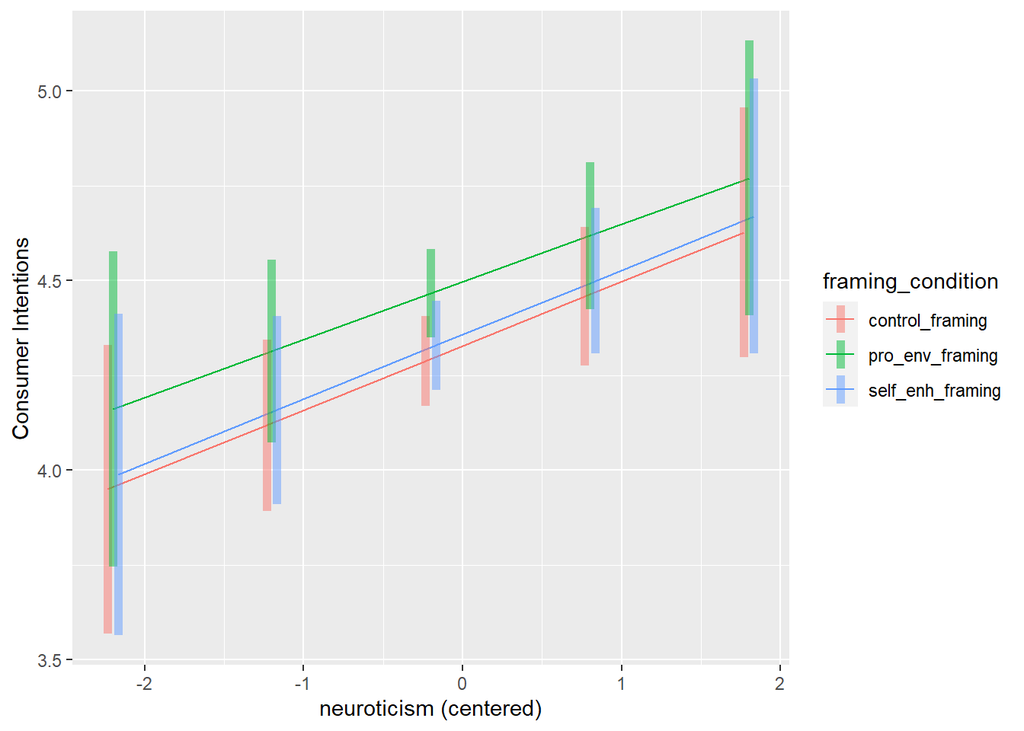

```r
# On a single graph
at_list <- list(neuroticism_center = seq(-2.2, 2.1, by = 1))

emmip(mod_mice, framing_condition ~ neuroticism_center, at = at_list, CIs = TRUE, xlab = "neuroticism (centered)", ylab = "Consumer Intentions")
```

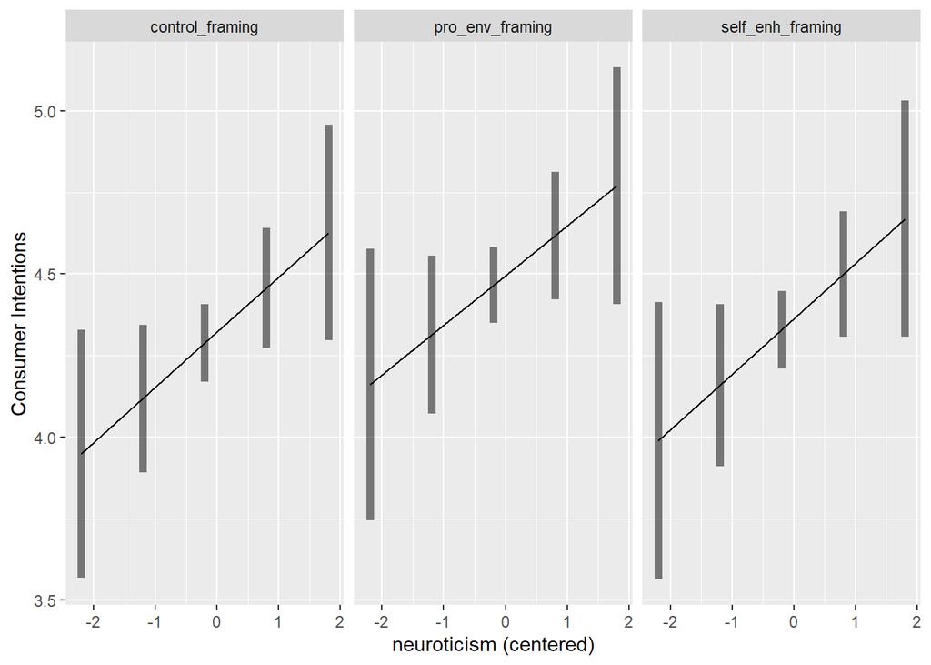

```r
# Separate graph for each norm
emmip(mod_mice, ~ neuroticism_center | framing_condition, at = at_list, CIs = TRUE, xlab = "neuroticism (centered)", ylab = "Consumer Intentions")
```

Is the slope of the relationship between neuroticism & consumer intentions stronger in any one of the framing conditions compared to the others?

```r
emtrends(mod_mice, pairwise~framing_condition, var = "neuroticism_center", adjust = "none")
```

```
## $emtrends
##  framing_condition neuroticism_center.trend     SE  df lower.CL upper.CL
##  control_framing                      0.169 0.0855 949  0.00159    0.337
##  pro_env_framing                      0.152 0.0949 949 -0.03407    0.338
##  self_enh_framing                     0.170 0.0959 949 -0.01793    0.359
##
## Results are averaged over the levels of: norm_condition, Gender
## Confidence level used: 0.95
##
## $contrasts
##  contrast                            estimate    SE  df t.ratio p.value
##  control_framing - pro_env_framing   0.017278 0.121 949   0.142  0.8868
##  control_framing - self_enh_framing -0.000974 0.122 949  -0.008  0.9936
##  pro_env_framing - self_enh_framing -0.018252 0.128 949  -0.143  0.8866
##
## Results are averaged over the levels of: norm_condition, Gender
```

Third, interaction between neuroticism, framing, & norm condition:

```r
emtrends(mod_mice, ~norm_condition | framing_condition, var = "neuroticism_center", adjust = "none")
```

```
## framing_condition = control_framing:
##  norm_condition   neuroticism_center.trend    SE  df lower.CL upper.CL
##  control_norm                      0.38793 0.173 949   0.0488    0.727
##  descriptive_norm                 -0.09699 0.200 949  -0.4901    0.296
##  convention_norm                   0.41435 0.189 949   0.0442    0.785
##  social_norm                       0.29972 0.165 949  -0.0238    0.623
##  moral_norm                       -0.15813 0.191 949  -0.5326    0.216
##
## framing_condition = pro_env_framing:
##  norm_condition   neuroticism_center.trend    SE  df lower.CL upper.CL
##  control_norm                      0.04974 0.187 949  -0.3176    0.417
##  descriptive_norm                 -0.02333 0.213 949  -0.4418    0.395
##  convention_norm                   0.41840 0.191 949   0.0437    0.793
##  social_norm                      -0.00744 0.233 949  -0.4638    0.449
##  moral_norm                        0.32312 0.189 949  -0.0477    0.694
##
## framing_condition = self_enh_framing:
##  norm_condition   neuroticism_center.trend    SE  df lower.CL upper.CL
##  control_norm                      0.14592 0.213 949  -0.2721    0.564
##  descriptive_norm                  0.27964 0.181 949  -0.0764    0.636
##  convention_norm                   0.11842 0.207 949  -0.2885    0.525
##  social_norm                      -0.15166 0.238 949  -0.6192    0.316
##  moral_norm                        0.45942 0.182 949   0.1022    0.817
##
## Results are averaged over the levels of: Gender
## Confidence level used: 0.95
```

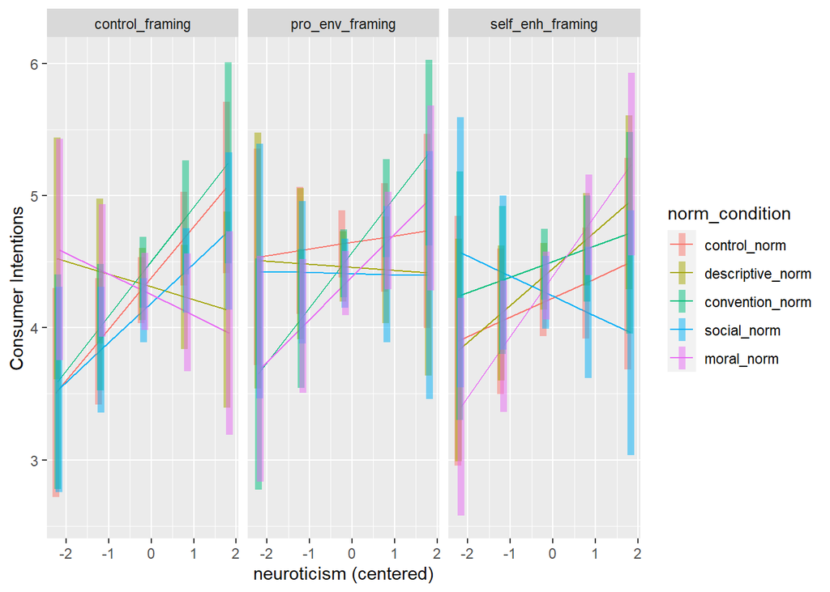

```r
# Separate graph for each framing condition
at_list <- list(neuroticism_center = seq(-2.2, 2.1, by = 1))

emmip(mod_mice, norm_condition ~ neuroticism_center | framing_condition, at = at_list, CIs = TRUE, xlab = "neuroticism (centered)", ylab = "Consumer Intentions")
```

### Honesty

First, relationship between honesty & consumer intentions for each norm condition:

```r
emtrends(mod_mice, ~norm_condition, var = "honesty_center", adjust = "none")
```

```
##  norm_condition   honesty_center.trend    SE  df lower.CL upper.CL
##  control_norm                   0.0152 0.119 949   -0.219   0.2493
##  descriptive_norm              -0.1961 0.121 949   -0.434   0.0420
##  convention_norm               -0.3272 0.119 949   -0.561  -0.0936
##  social_norm                   -0.0603 0.117 949   -0.289   0.1687
##  moral_norm                    -0.0533 0.128 949   -0.304   0.1973
##
## Results are averaged over the levels of: framing_condition, Gender
## Confidence level used: 0.95
```

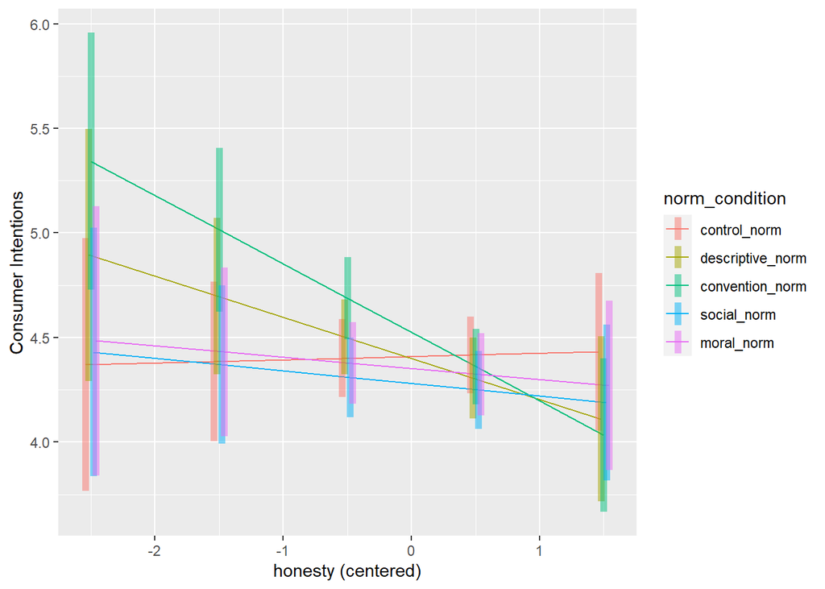

```r
# On a single graph
at_list <- list(honesty_center = seq(-2.5, 1.6, by = 1))

emmip(mod_mice, norm_condition ~ honesty_center, at = at_list, CIs = TRUE, xlab = "honesty (centered)", ylab = "Consumer Intentions")
```

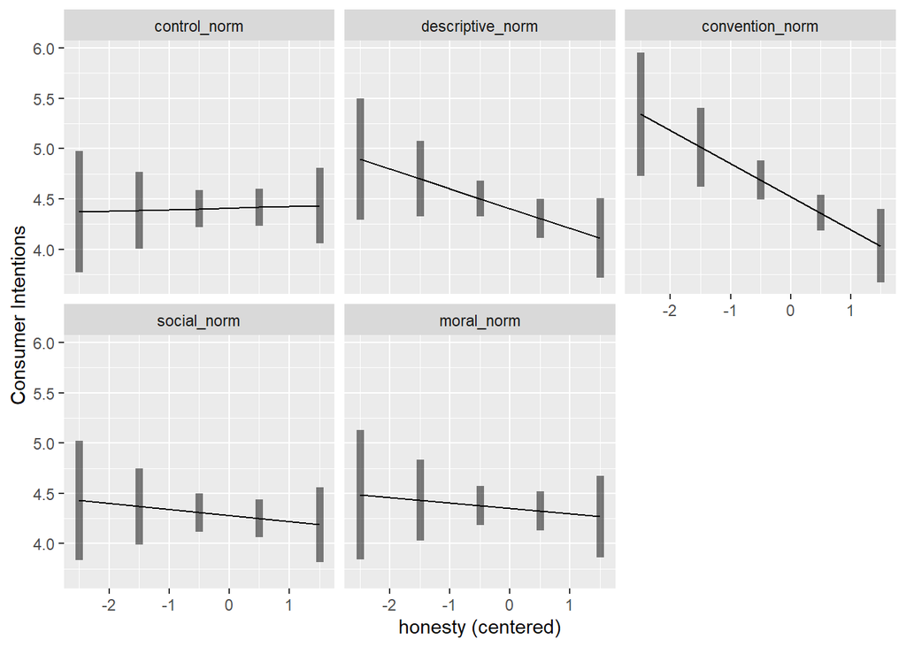

```r
# Separate graph for each norm
emmip(mod_mice, ~ honesty_center | norm_condition, at = at_list, CIs = TRUE, xlab = "honesty (centered)", ylab = "Consumer Intentions")
```

Is the slope of the relationship between honesty & consumer intentions stronger in any one of the norm conditions compared to the others?

```r
emtrends(mod_mice, pairwise~norm_condition, var = "honesty_center", adjust = "none")
```

```
## $emtrends
##  norm_condition   honesty_center.trend    SE  df lower.CL upper.CL
##  control_norm                   0.0152 0.119 949   -0.219   0.2493
##  descriptive_norm              -0.1961 0.121 949   -0.434   0.0420
##  convention_norm               -0.3272 0.119 949   -0.561  -0.0936
##  social_norm                   -0.0603 0.117 949   -0.289   0.1687
##  moral_norm                    -0.0533 0.128 949   -0.304   0.1973
##
## Results are averaged over the levels of: framing_condition, Gender
## Confidence level used: 0.95
##
## $contrasts
##  contrast                           estimate    SE  df t.ratio p.value
##  control_norm - descriptive_norm     0.21128 0.169 949   1.253  0.2103
##  control_norm - convention_norm      0.34243 0.168 949   2.040  0.0416
##  control_norm - social_norm          0.07551 0.165 949   0.457  0.6477
##  control_norm - moral_norm           0.06853 0.174 949   0.395  0.6930
##  descriptive_norm - convention_norm  0.13114 0.169 949   0.777  0.4372
##  descriptive_norm - social_norm     -0.13578 0.166 949  -0.820  0.4126
##  descriptive_norm - moral_norm      -0.14275 0.174 949  -0.818  0.4133
##  convention_norm - social_norm      -0.26692 0.165 949  -1.620  0.1057
##  convention_norm - moral_norm       -0.27389 0.174 949  -1.577  0.1151
##  social_norm - moral_norm           -0.00697 0.171 949  -0.041  0.9675
##
## Results are averaged over the levels of: framing_condition, Gender
```

Second, relationship between honesty & consumer intentions for each framing condition:

```r
emtrends(mod_mice, ~framing_condition, var = "honesty_center", adjust = "none")
```

```
##  framing_condition honesty_center.trend     SE  df lower.CL upper.CL
##  control_framing                 -0.039 0.0928 949   -0.221   0.1432
##  pro_env_framing                 -0.123 0.0902 949   -0.300   0.0537
##  self_enh_framing                -0.211 0.0990 949   -0.405  -0.0164
##
## Results are averaged over the levels of: norm_condition, Gender
## Confidence level used: 0.95
```

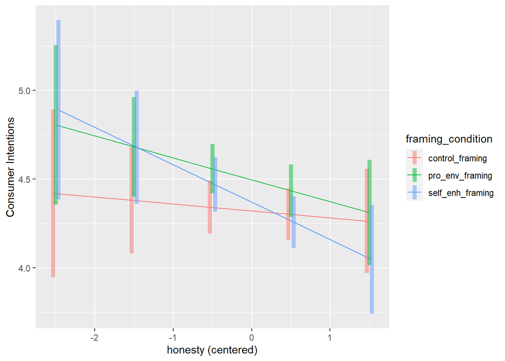

```r
# On a single graph
at_list <- list(honesty_center = seq(-2.5, 1.6, by = 1))

emmip(mod_mice, framing_condition ~ honesty_center, at = at_list, CIs = TRUE, xlab = "honesty (centered)", ylab = "Consumer Intentions")
```

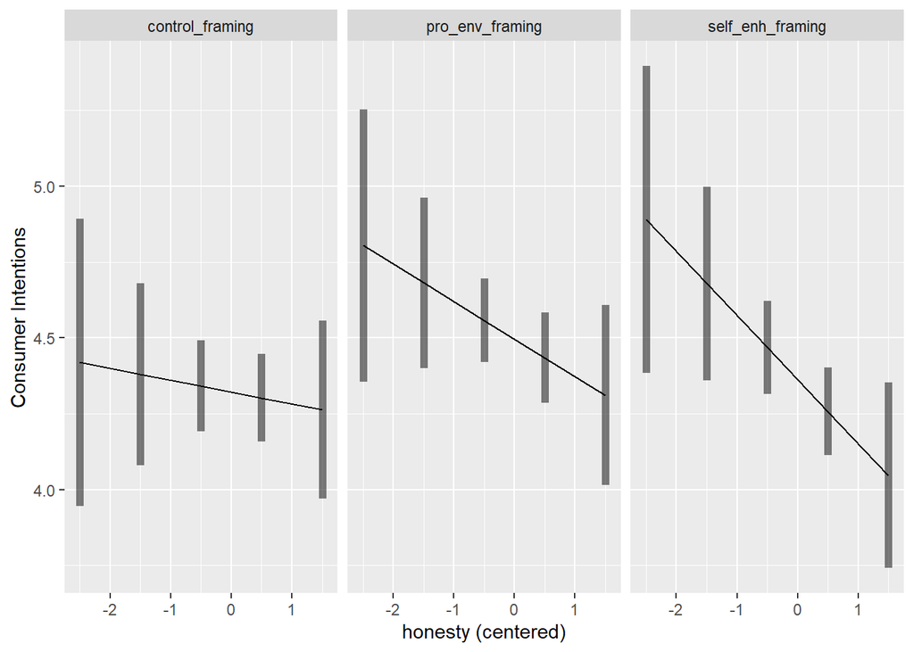

```r
# Separate graph for each norm
emmip(mod_mice, ~ honesty_center | framing_condition, at = at_list, CIs = TRUE, xlab = "honesty (centered)", ylab = "Consumer Intentions")
```

Is the slope of the relationship between honesty & consumer intentions stronger in any one of the framing conditions compared to the others?

```r
emtrends(mod_mice, pairwise~framing_condition, var = "honesty_center", adjust = "none")
```

```
## $emtrends
##  framing_condition honesty_center.trend     SE  df lower.CL upper.CL
##  control_framing                 -0.039 0.0928 949   -0.221   0.1432
##  pro_env_framing                 -0.123 0.0902 949   -0.300   0.0537
##  self_enh_framing                -0.211 0.0990 949   -0.405  -0.0164
##
## Results are averaged over the levels of: norm_condition, Gender
## Confidence level used: 0.95
##
## $contrasts
##  contrast                           estimate    SE  df t.ratio p.value
##  control_framing - pro_env_framing    0.0844 0.128 949   0.662  0.5084
##  control_framing - self_enh_framing   0.1718 0.133 949   1.289  0.1977
##  pro_env_framing - self_enh_framing   0.0874 0.132 949   0.663  0.5077
##
## Results are averaged over the levels of: norm_condition, Gender
```

Third, interaction between honesty, framing, & norm condition:

```r
emtrends(mod_mice, ~norm_condition | framing_condition, var = "honesty_center", adjust = "none")
```

```
## framing_condition = control_framing:
##  norm_condition   honesty_center.trend    SE  df lower.CL upper.CL
##  control_norm                  -0.0044 0.190 949   -0.378   0.3692
##  descriptive_norm              -0.0890 0.239 949   -0.557   0.3795
##  convention_norm               -0.0699 0.193 949   -0.450   0.3098
##  social_norm                   -0.0905 0.162 949   -0.408   0.2268
##  moral_norm                     0.0589 0.232 949   -0.396   0.5135
##
## framing_condition = pro_env_framing:
##  norm_condition   honesty_center.trend    SE  df lower.CL upper.CL
##  control_norm                  -0.0325 0.207 949   -0.439   0.3737
##  descriptive_norm              -0.3993 0.174 949   -0.741  -0.0575
##  convention_norm               -0.4434 0.195 949   -0.826  -0.0604
##  social_norm                    0.1694 0.222 949   -0.267   0.6057
##  moral_norm                     0.0891 0.198 949   -0.300   0.4781
##
## framing_condition = self_enh_framing:
##  norm_condition   honesty_center.trend    SE  df lower.CL upper.CL
##  control_norm                   0.0825 0.220 949   -0.348   0.5133
##  descriptive_norm              -0.1001 0.209 949   -0.509   0.3092
##  convention_norm               -0.4684 0.227 949   -0.913  -0.0233
##  social_norm                   -0.2598 0.207 949   -0.667   0.1470
##  moral_norm                    -0.3081 0.229 949   -0.758   0.1420
##
## Results are averaged over the levels of: Gender
## Confidence level used: 0.95
```

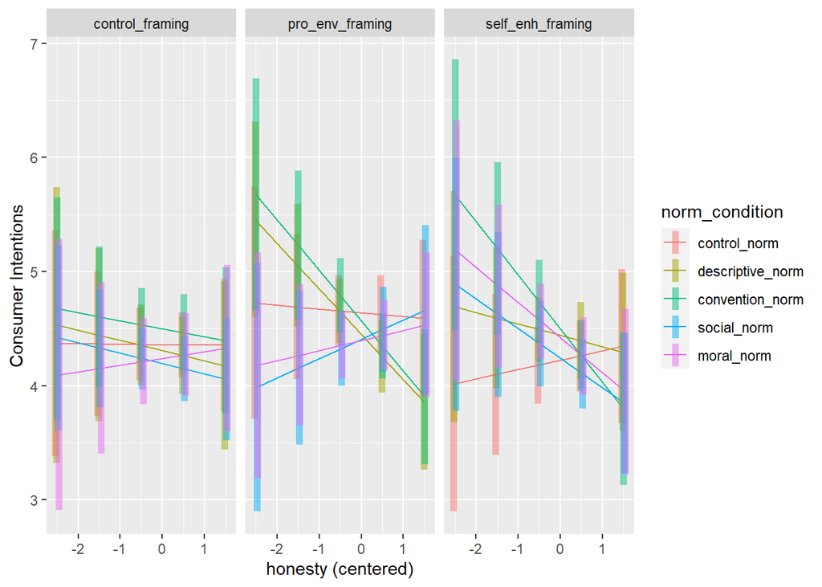

```r
# Separate graph for each framing condition
at_list <- list(honesty_center = seq(-2.5, 1.6, by = 1))

emmip(mod_mice, norm_condition ~ honesty_center | framing_condition, at = at_list, CIs = TRUE, xlab = "honesty (centered)", ylab = "Consumer Intentions")
```